# Velmyra contra VRS-X

Hugo Granchetti, Ignacio Monteros Domogalla (Grupo E)

# Carga de datos

```r
url_csv <- "https://velmyra.netlify.app/datos/cohorte_fase4.csv"
df <- read_csv(url_csv, show_col_types = FALSE)

# Verificación rápida de columnas esperadas

cols_esperadas <- c("hospitalizada", "vacunada", "edad", "sexo",
                    "comorbilidad", "centro", "dias_desde_vacunacion")

faltantes <- setdiff(cols_esperadas, names(df))

if (length(faltantes) > 0) {
  warning("Columnas faltantes: ", paste(faltantes, collapse = ", "),
          "\n  Verificar diccionario.md del IICA")
}

cat("Dimensiones del dataset:", nrow(df), "filas x", ncol(df), "columnas\n")
```

```
## Dimensiones del dataset: 10234 filas x 10 columnas
```

```r
glimpse(df)
```

```
## Rows: 10,234
## Columns: 10
## $ id                    <dbl> 1, 2, 3, 4, 5, 6, 7, 8, 9, 10, 11, 12, 13, 14, 1…
## $ edad                  <dbl> 81, 54, 71, 68, 63, 81, 61, 82, 89, 50, 48, 65, …
## $ sexo                  <chr> "M", "M", "F", "M", "M", "F", "M", "M", "F", "F"…
## $ comorbilidad          <dbl> 0, 0, 0, 0, 0, 1, 0, 1, 0, 1, 0, 0, 0, 1, 0, 0, …
## $ centro                <chr> "C03", "C03", "C03", "C10", "C02", "C05", "C03",…
## $ vacunada              <dbl> 0, 1, 0, 1, 0, 0, 1, 1, 1, 1, 0, 0, 0, 0, 0, 0, …
## $ dias_desde_vacunacion <dbl> -1, 77, -1, 73, -1, -1, 286, 179, 293, 84, -1, -…
## $ mes_inclusion         <dbl> 2, 10, 2, 12, 10, 12, 5, 3, 6, 10, 2, 4, 7, 2, 7…
## $ expuesto              <dbl> 0, 0, 0, 0, 0, 0, 0, 0, 0, 0, 0, 0, 0, 0, 0, 0, …
## $ hospitalizada         <dbl> 0, 0, 0, 0, 0, 0, 0, 0, 0, 0, 0, 0, 0, 0, 0, 0, …
```

# Análisis exploratorio de datos (EDA)

## Variables auxiliares para el EDA

```r
bins_vacunados <- c("0-90", "91-180", "181-270", "271-365")
niveles_exposicion_tiempo <- c("No vacunada", bins_vacunados)

df <- df %>%
  mutate(
    edad_cat = cut(
      edad,
      breaks = c(17, 49, 69, 100),
      labels = c("18-49", "50-69", "70+")
    ),

    bin_tiempo = case_when(
      vacunada == 0 ~ "No vacunada",
      vacunada == 1 & dias_desde_vacunacion >= 0   & dias_desde_vacunacion <= 90  ~ "0-90",
      vacunada == 1 & dias_desde_vacunacion >= 91  & dias_desde_vacunacion <= 180 ~ "91-180",
      vacunada == 1 & dias_desde_vacunacion >= 181 & dias_desde_vacunacion <= 270 ~ "181-270",
      vacunada == 1 & dias_desde_vacunacion >= 271 & dias_desde_vacunacion <= 365 ~ "271-365",
      TRUE ~ NA_character_
    ),
    bin_tiempo = factor(
      bin_tiempo,
      levels = niveles_exposicion_tiempo
    )
  )
```

## Calidad de datos

```r
# Revisar valores faltantes y unicidad
tabla_nulls <- tibble(
  columna = names(df),
  cantidad_na = as.integer(sapply(df, function(columna) sum(is.na(columna)))),
  valores_distintos = as.integer(sapply(df, function(columna) n_distinct(columna)))
)

tabla_nulls <- tabla_nulls %>%
  mutate(porcentaje_na = round(100 * cantidad_na / nrow(df), 2)) %>%
  dplyr::select(columna, cantidad_na, porcentaje_na, valores_distintos)

tabla_nulls
```

| columna | cantidad_na | porcentaje_na | valores_distintos |
| --- | --- | --- | --- |
| id | 0 | 0 | 10234 |
| edad | 0 | 0 | 78 |
| sexo | 0 | 0 | 2 |
| comorbilidad | 0 | 0 | 2 |
| centro | 0 | 0 | 12 |
| vacunada | 0 | 0 | 2 |
| dias_desde_vacunacion | 0 | 0 | 366 |
| mes_inclusion | 0 | 0 | 12 |
| expuesto | 0 | 0 | 2 |
| hospitalizada | 0 | 0 | 2 |

[output cut: 2 more lines]

```r
# id se revisa como identificador, no como variable analítica.
tabla_id <- df %>%
  summarise(
    filas = n(),
    ids_distintos = n_distinct(id),
    id_minimo = min(id),
    id_maximo = max(id)
  )

tabla_id
```

| filas | ids_distintos | id_minimo | id_maximo |
| --- | --- | --- | --- |
| 10234 | 10234 | 1 | 10234 |

```r
# Verificar que dias_desde_vacunacion == -1 identifica a no vacunados.
tabla_estado_vacunacion_tiempo <- df %>%
  mutate(
    estado_vacunacion = case_when(
      dias_desde_vacunacion == -1 ~ "No vacunada",
      dias_desde_vacunacion >= 0 & dias_desde_vacunacion <= 365 ~ "Vacunada",
      TRUE ~ "Valor faltante o fuera de rango"
    )
  ) %>%
  count(estado_vacunacion, name = "cantidad")

tabla_estado_vacunacion_tiempo
```

| estado_vacunacion | cantidad |
| --- | --- |
| No vacunada | 4336 |
| Vacunada | 5898 |

## Distribuciones básicas

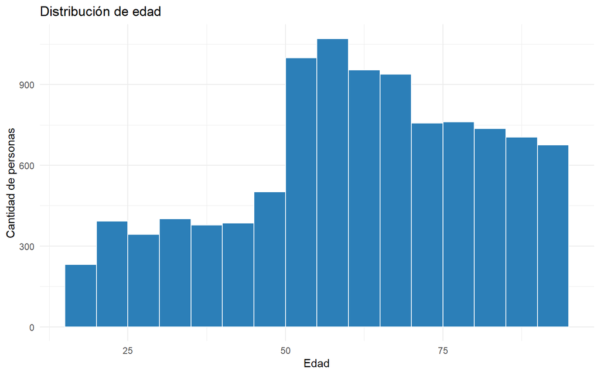

```r
# Distribución de edades.
grafico_edad <- ggplot(df, aes(x = edad)) +
  geom_histogram(binwidth = 5, boundary = 0, fill = "#2C7FB8", color = "white") +
  labs(
    title = "Distribuci\u00f3n de edad",
    x = "Edad",
    y = "Cantidad de personas"
  ) +
  theme_minimal()

print(grafico_edad)
```

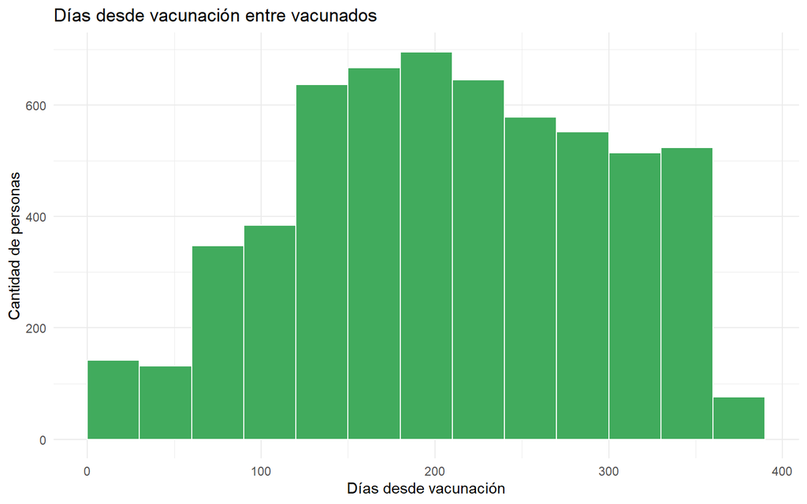

```r
# Distribución del tiempo desde vacunación solo entre vacunados.
df_eda_vacunados <- df %>%
  filter(vacunada == 1)

grafico_dias_vacunados <- ggplot(df_eda_vacunados, aes(x = dias_desde_vacunacion)) +
  geom_histogram(binwidth = 30, boundary = 0, fill = "#41AB5D", color = "white") +
  labs(
    title = "D\u00edas desde vacunaci\u00f3n entre vacunados",
    x = "D\u00edas desde vacunaci\u00f3n",
    y = "Cantidad de personas"
  ) +
  theme_minimal()

print(grafico_dias_vacunados)
```

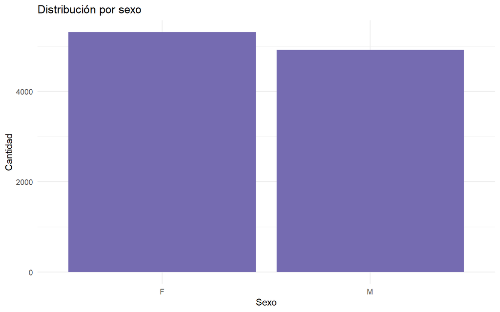

```r
# Barras para variables categóricas principales.
grafico_sexo <- ggplot(df, aes(x = sexo)) +
  geom_bar(fill = "#756BB1") +
  labs(title = "Distribuci\u00f3n por sexo", x = "Sexo", y = "Cantidad") +
  theme_minimal()

grafico_comorbilidad <- ggplot(df, aes(x = factor(comorbilidad))) +
  geom_bar(fill = "#756BB1") +
  labs(title = "Distribuci\u00f3n por comorbilidad", x = "Comorbilidad", y = "Cantidad") +
  theme_minimal()

grafico_centro <- ggplot(df, aes(x = factor(centro))) +
  geom_bar(fill = "#756BB1") +
  labs(title = "Distribuci\u00f3n por centro", x = "Centro", y = "Cantidad") +
  theme_minimal()

grafico_vacunada <- ggplot(df, aes(x = factor(vacunada))) +
  geom_bar(fill = "#756BB1") +
  labs(title = "Distribuci\u00f3n por vacunaci\u00f3n", x = "Vacunada", y = "Cantidad") +
  theme_minimal()

grafico_mes_inclusion <- ggplot(df, aes(x = factor(mes_inclusion))) +
  geom_bar(fill = "#756BB1") +
  labs(title = "Distribuci\u00f3n por mes de inclusi\u00f3n", x = "Mes de inclusi\u00f3n", y = "Cantidad") +
  theme_minimal()

grafico_expuesto <- ggplot(df, aes(x = factor(expuesto))) +
  geom_bar(fill = "#756BB1") +
  labs(title = "Distribuci\u00f3n por exposici\u00f3n", x = "Expuesto", y = "Cantidad") +
  theme_minimal()

grafico_hospitalizada <- ggplot(df, aes(x = factor(hospitalizada))) +
  geom_bar(fill = "#756BB1") +
  labs(title = "Distribuci\u00f3n por hospitalizaci\u00f3n", x = "Hospitalizada", y = "Cantidad") +
  theme_minimal()

print(grafico_sexo)
```

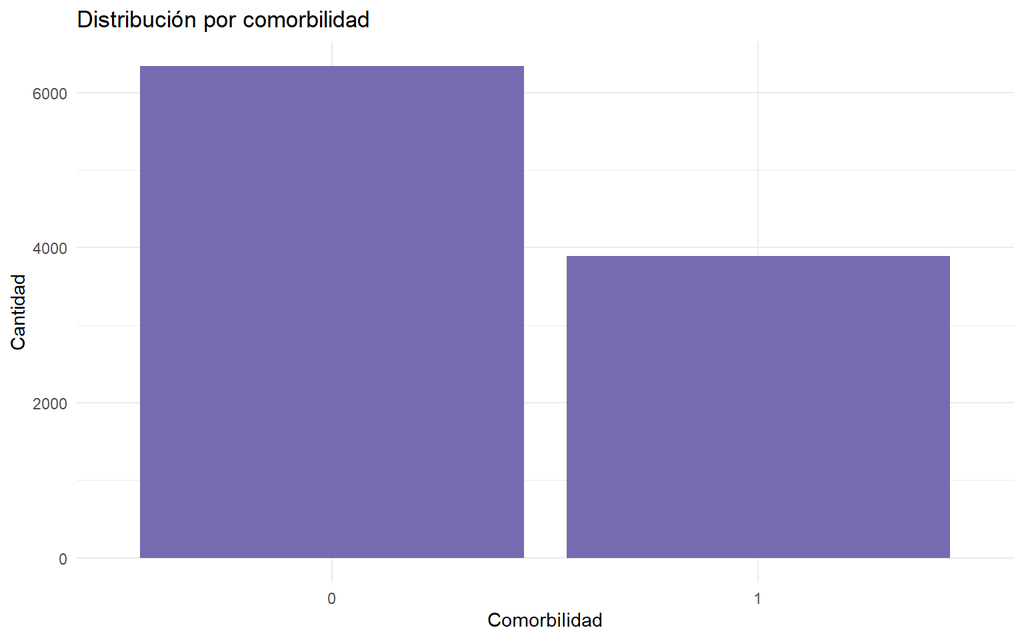

```r
print(grafico_comorbilidad)
```

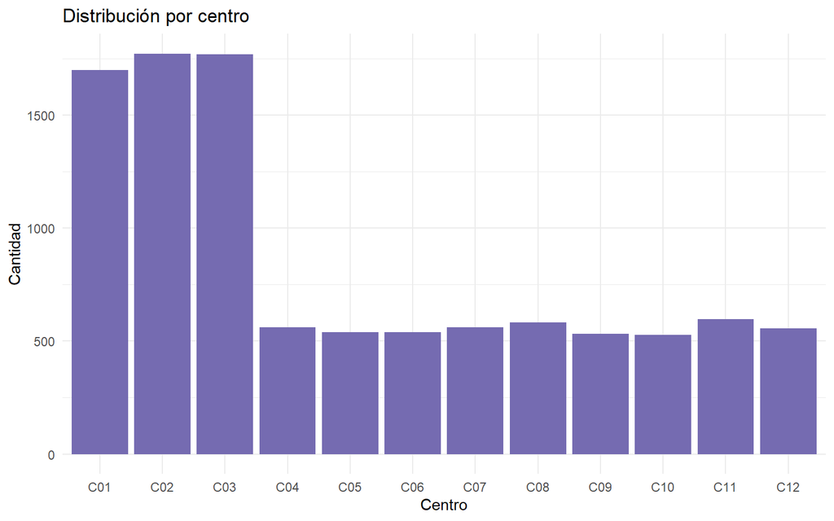

```r
print(grafico_centro)
```

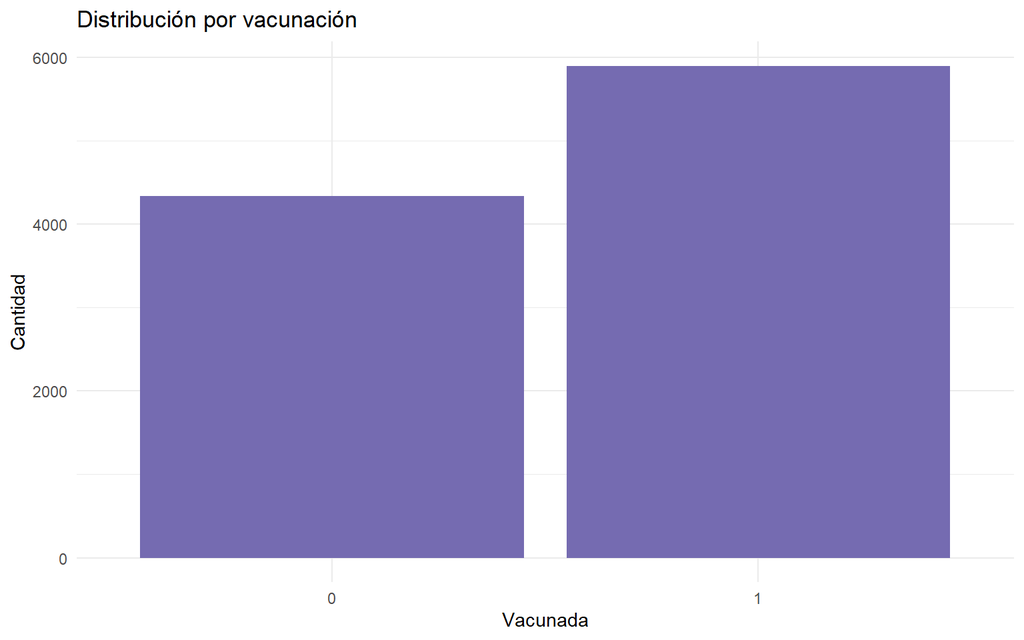

```r
print(grafico_vacunada)
```

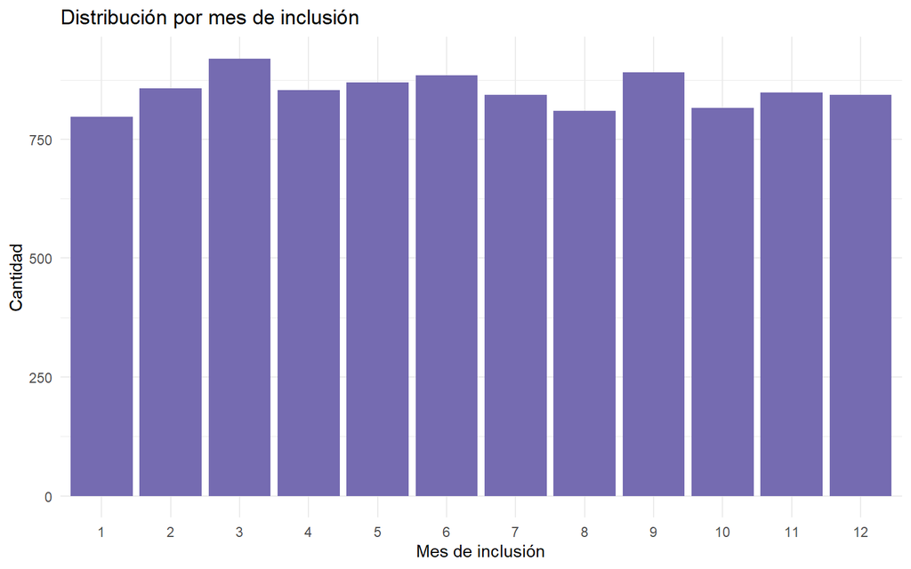

```r
print(grafico_mes_inclusion)
```

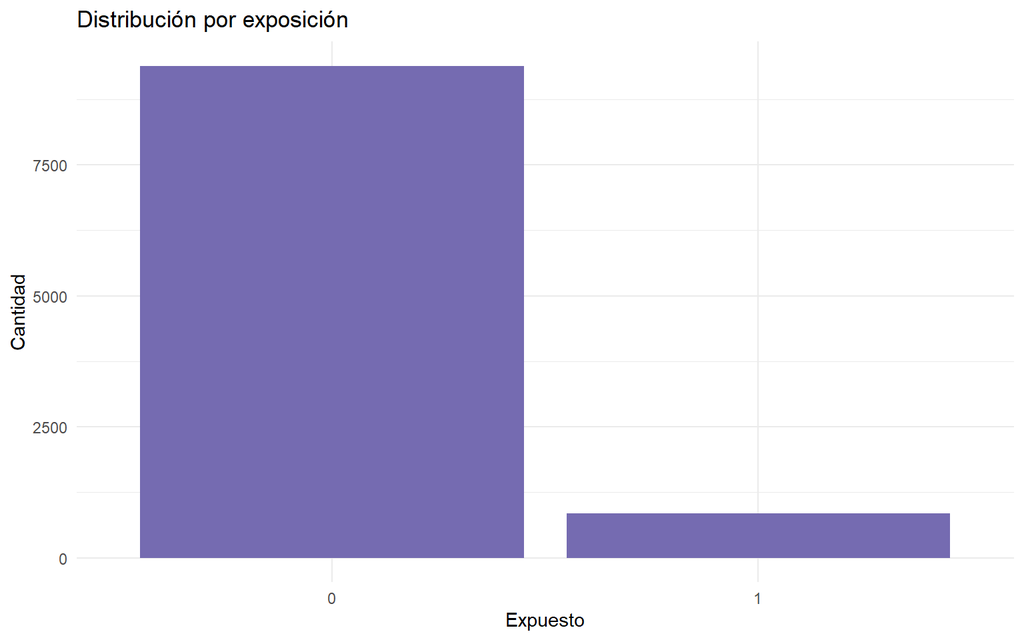

```r
print(grafico_expuesto)
```

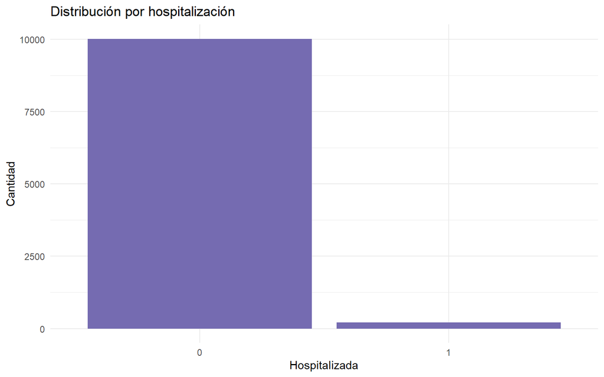

```r
print(grafico_hospitalizada)
```

## Proporciones principales

```r
# Tasa de hospitalización por estado de vacunación.
tabla_hospitalizacion_vacunada <- df %>%
  group_by(vacunada) %>%
  summarise(
    total = n(),
    hospitalizados = sum(hospitalizada == 1),
    proporcion_hospitalizada = hospitalizados / total,
    .groups = "drop"
  ) %>%
  mutate(
    grupo_vacunacion = if_else(vacunada == 1, "Vacunada", "No vacunada"),
    etiqueta = paste0(hospitalizados, " / ", total)
  )

tabla_hospitalizacion_vacunada
```

| vacunada | total | hospitalizados | proporcion_hospitalizada | grupo_vacunacion | etiqueta |
| --- | --- | --- | --- | --- | --- |
| 0 | 4336 | 141 | 0.03251845 | No vacunada | 141 / 4336 |
| 1 | 5898 | 74 | 0.01254663 | Vacunada | 74 / 5898 |

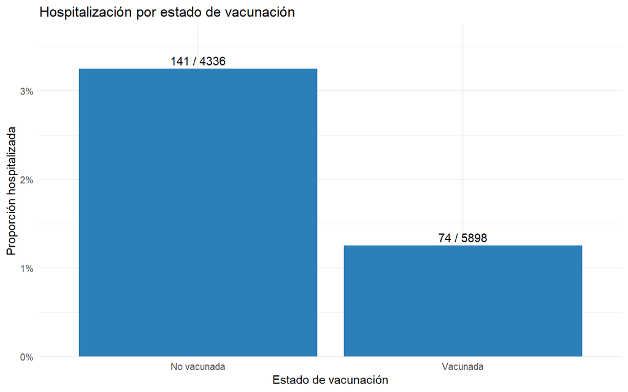

```r
grafico_hospitalizacion_vacunada <- ggplot(
  tabla_hospitalizacion_vacunada,
  aes(x = grupo_vacunacion, y = proporcion_hospitalizada)
) +
  geom_col(fill = "#2C7FB8") +
  geom_text(aes(label = etiqueta), vjust = -0.4) +
  scale_y_continuous(
    labels = function(x) paste0(round(100 * x, 1), "%"),
    expand = expansion(mult = c(0, 0.15))
  ) +
  labs(
    title = "Hospitalizaci\u00f3n por estado de vacunaci\u00f3n",
    x = "Estado de vacunaci\u00f3n",
    y = "Proporci\u00f3n hospitalizada"
  ) +
  theme_minimal()

print(grafico_hospitalizacion_vacunada)
```

```r
# Tasa de hospitalización entre vacunados por tiempo desde vacunación.
tabla_hospitalizacion_tiempo <- df %>%
  filter(vacunada == 1) %>%
  group_by(bin_tiempo) %>%
  summarise(
    total = n(),
    hospitalizados = sum(hospitalizada == 1),
    proporcion_hospitalizada = hospitalizados / total,
    .groups = "drop"
  ) %>%
  mutate(etiqueta = paste0(hospitalizados, " / ", total))

tabla_hospitalizacion_tiempo
```

| bin_tiempo | total | hospitalizados | proporcion_hospitalizada | etiqueta |
| --- | --- | --- | --- | --- |
| 0-90 | 622 | 2 | 0.003215434 | 2 / 622 |
| 91-180 | 1688 | 16 | 0.009478673 | 16 / 1688 |
| 181-270 | 1921 | 28 | 0.014575742 | 28 / 1921 |
| 271-365 | 1667 | 28 | 0.016796641 | 28 / 1667 |

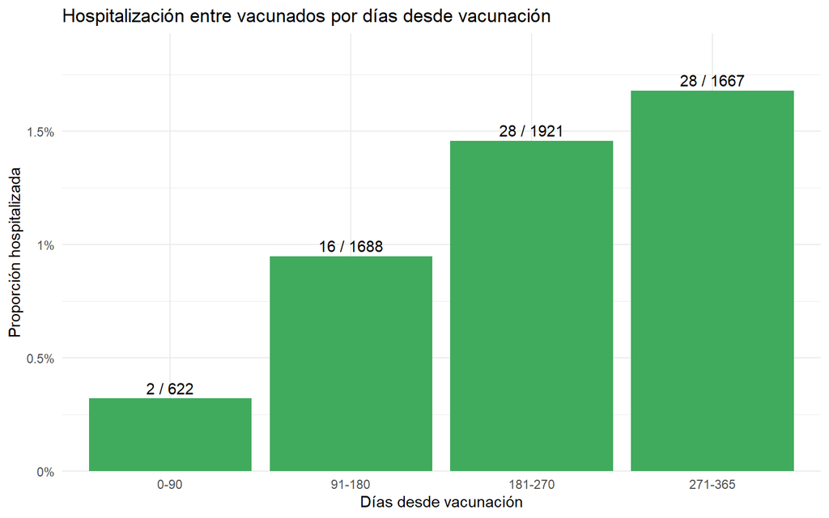

```r
grafico_hospitalizacion_tiempo <- ggplot(
  tabla_hospitalizacion_tiempo,
  aes(x = bin_tiempo, y = proporcion_hospitalizada)
) +
  geom_col(fill = "#41AB5D") +
  geom_text(aes(label = etiqueta), vjust = -0.4) +
  scale_y_continuous(
    labels = function(x) paste0(round(100 * x, 1), "%"),
    expand = expansion(mult = c(0, 0.15))
  ) +
  labs(
    title = "Hospitalizaci\u00f3n entre vacunados por d\u00edas desde vacunaci\u00f3n",
    x = "D\u00edas desde vacunaci\u00f3n",
    y = "Proporci\u00f3n hospitalizada"
  ) +
  theme_minimal()

print(grafico_hospitalizacion_tiempo)
```

## Hospitalizados no vacunados por rango etario

```r
# Mirar no vacunados por grupo de edad da otra perspectiva del riesgo base.
tabla_no_vacunados_edad <- df %>%
  filter(vacunada == 0) %>%
  group_by(edad_cat) %>%
  summarise(
    total = n(),
    hospitalizados = sum(hospitalizada == 1),
    proporcion_hospitalizada = hospitalizados / total,
    .groups = "drop"
  ) %>%
  mutate(etiqueta = paste0(hospitalizados, " / ", total))

tabla_no_vacunados_edad
```

| edad_cat | total | hospitalizados | proporcion_hospitalizada | etiqueta |
| --- | --- | --- | --- | --- |
| 18-49 | 1399 | 18 | 0.01286633 | 18 / 1399 |
| 50-69 | 1804 | 55 | 0.03048780 | 55 / 1804 |
| 70+ | 1133 | 68 | 0.06001765 | 68 / 1133 |

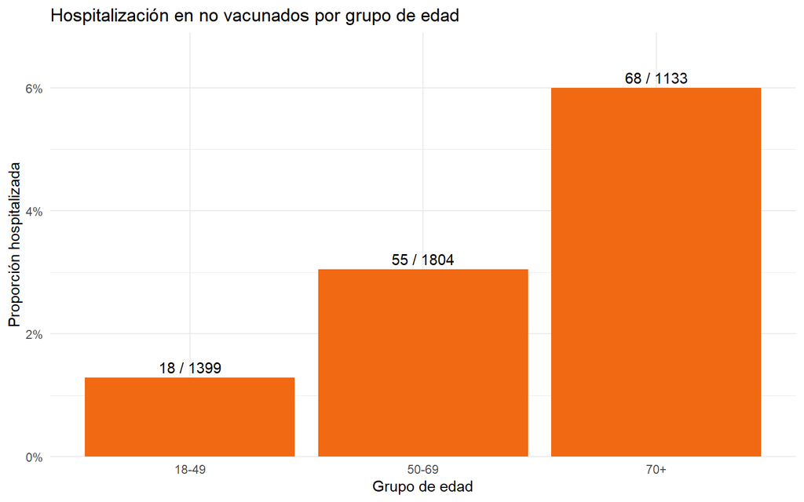

```r
grafico_no_vacunados_edad <- ggplot(
  tabla_no_vacunados_edad,
  aes(x = edad_cat, y = proporcion_hospitalizada)
) +
  geom_col(fill = "#F16913") +
  geom_text(aes(label = etiqueta), vjust = -0.4) +
  scale_y_continuous(
    labels = function(x) paste0(round(100 * x, 1), "%"),
    expand = expansion(mult = c(0, 0.15))
  ) +
  labs(
    title = "Hospitalizaci\u00f3n en no vacunados por grupo de edad",
    x = "Grupo de edad",
    y = "Proporci\u00f3n hospitalizada"
  ) +
  theme_minimal()

print(grafico_no_vacunados_edad)
```

# PASO 1 — Reproducción del modelo frecuentista oficial

```
Modelo oficial publicado: hospitalizada ~ vacunada + edad_cat + sexo + comorbilidad + centro
```

```
OR vacunada       : 0.282
```

```
IC Wald 95% OR    : [0.211, 0.378]
```

```
VE = 1 - OR       : 71.8%
```

```
IC Wald 95% VE   : [62.2%, 78.9%]
```

```
p-valor Wald      : 2.1e-17
```

```
Esperado: OR ≈ 0.28, IC95% OR ≈ [0.21, 0.38], VE ≈ 72%, IC ≈ [62%, 79%]
```

# PASO 2 — Posterior bayesiano vía aproximación cuadrática (rethinking::quap)

```r
# ---- Priors fase III (se calculan aquí, se reutilizan en paso 6) ----
# VE_fase3 = 81%  =>  OR = 1 - 0.81 = 0.19  =>  βV = log(0.19) ≈ -1.66
# IC95% VE [73%, 87%]  =>  OR ∈ [0.13, 0.27]  =>  βV ∈ [log(0.13), log(0.27)]
# SE_βV ≈ (log(0.27) - log(0.13)) / (2 * 1.96) ≈ 0.19

prior_mu_V_informado <- log(1 - 0.81)
prior_sd_V_informado <- (log(1 - 0.73) - log(1 - 0.87)) / (2 * 1.96)

cat(sprintf(
  "Prior informado fase III $\\beta_V \\sim N(%.2f, %.2f^{2})$",
  prior_mu_V_informado,
  prior_sd_V_informado
))
```

Prior informado fase III $\beta_V \sim N(-1.66, 0.19^{2})$

```r
# ---- Preparar data list que quap necesita ----
# quap no acepta data frames directamente; requiere una lista con vectores.
# El modelo bayesiano replica la estructura principal del oficial:
# vacunada + edad_cat + sexo + comorbilidad.
# Omite centro para evitar una parametrización extensa en quap; por eso el HPDI
# se compara con el Wald oficial como aproximación cercana, no como igualdad exacta.

dat <- list(
  hospitalizada = as.integer(df$hospitalizada),
  vacunada      = as.integer(df$vacunada),
  edad_50_69    = as.integer(df$edad_cat == "50-69"),
  edad_70_plus  = as.integer(df$edad_cat == "70+"),
  sexo          = as.integer(factor(df$sexo)) - 1L,
  comorbilidad  = as.integer(df$comorbilidad)
)
```

```r
# ---- Modelo quap con prior débil sobre todos los coeficientes ----
# quap toma una lista de fórmulas: verosimilitud, predictor lineal y priors.

modelo_quap_debil <- quap(
    alist(
      hospitalizada ~ dbinom(1, p),
      logit(p) <- a +
        bV * vacunada +
        bE50 * edad_50_69 +
        bE70 * edad_70_plus +
        bS * sexo +
        bCom * comorbilidad,

      a ~ dnorm(0, 2.5),
      bV ~ dnorm(0, 2.5),
      bE50 ~ dnorm(0, 2.5),
      bE70 ~ dnorm(0, 2.5),
      bS ~ dnorm(0, 2.5),
      bCom ~ dnorm(0, 2.5)
    ),
    data = dat
  )
```

```r
# ---- Modelo quap con prior informado fase III solo para βV ----

modelo_quap_informado <- quap(
    alist(
      hospitalizada ~ dbinom(1, p),
      logit(p) <- a +
        bV * vacunada +
        bE50 * edad_50_69 +
        bE70 * edad_70_plus +
        bS * sexo +
        bCom * comorbilidad,

      a ~ dnorm(0, 2.5),
      bV ~ dnorm(prior_mu_V_informado, prior_sd_V_informado),
      bE50 ~ dnorm(0, 2.5),
      bE70 ~ dnorm(0, 2.5),
      bS ~ dnorm(0, 2.5),
      bCom ~ dnorm(0, 2.5)
    ),
    data = dat
  )
```

```
-- Prior DÉBIL --
           mean        sd        2.5%      97.5%
a    -4.3936831 0.2327732 -4.84991024 -3.9374559
bV   -1.2513951 0.1482401 -1.54194044 -0.9608498
bE50  0.9195332 0.2516636  0.42628149  1.4127848
bE70  1.5030512 0.2560030  1.00129458  2.0048078
bS   -0.1571235 0.1393066 -0.43015937  0.1159123
bCom  0.3706995 0.1519962  0.07279246  0.6686066

-- Prior INFORMADO (fase III) en beta_V --
           mean        sd        2.5%      97.5%
a    -4.3686439 0.2321944 -4.82373650 -3.9135513
bV   -1.4150300 0.1179291 -1.64616683 -1.1838931
bE50  0.9314679 0.2516400  0.43826246  1.4246733
bE70  1.5337664 0.2554448  1.03310376  2.0344291
bS   -0.1564028 0.1394869 -0.42979210  0.1169866
bCom  0.3866827 0.1519130  0.08893872  0.6844267
```

```
Prior DÉBIL     — MAP VE: 71.4%  |  HPDI 95%: [62.4%, 79.2%]
```

```
Prior INFORMADO — MAP VE: 75.7%  |  HPDI 95%: [69.8%, 81.1%]
```

```
IC Wald frecuentista: [62.2%, 78.9%]
```

```
Nota: el HPDI se compara con el Wald oficial como aproximación cercana, no como igualdad exacta, porque el modelo quap omite centro. Pero solo el HPDI admite lectura de CREENCIA: '95% de probabilidad de que VE ∈ [x, y]'.
```

**Limitación**: cuidado con la validez externa del prior informado por fase III.

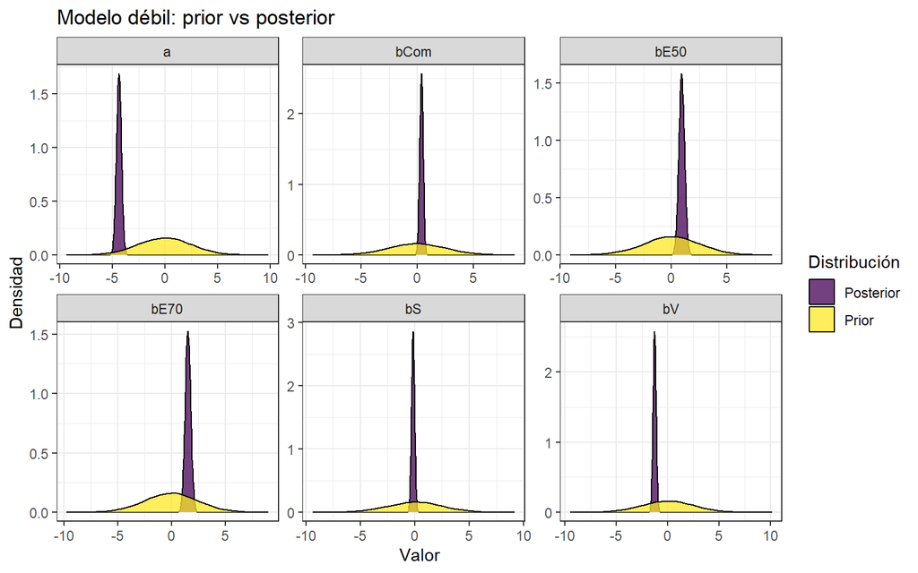

```r
# ---- Comparación prior vs posterior: modelo débil ----

  posterior_debil <- as_tibble(samp_debil) %>%
    dplyr::select(a, bV, bE50, bE70, bS, bCom) %>%
    mutate(distribucion = "Posterior")

  prior_debil <- tibble(
    a  = rnorm(N_samp, 0, 2.5),
    bV = rnorm(N_samp, 0, 2.5),
    bE50 = rnorm(N_samp, 0, 2.5),
    bE70 = rnorm(N_samp, 0, 2.5),
    bS = rnorm(N_samp, 0, 2.5),
    bCom = rnorm(N_samp, 0, 2.5),
    distribucion = "Prior"
  )

  long_prior_posterior_debil <- bind_rows(posterior_debil, prior_debil) %>%
    pivot_longer(
      cols = -distribucion,
      names_to = "variable",
      values_to = "value"
    )

  long_prior_posterior_debil %>%
    ggplot(aes(x = value, fill = distribucion)) +
    geom_density(alpha = 0.75) +
    theme_bw() +
    facet_wrap(variable ~ ., scales = "free") +
    labs(
      x = "Valor",
      y = "Densidad",
      fill = "Distribuci\u00f3n",
      title = "Modelo d\u00e9bil: prior vs posterior"
    ) +
    scale_fill_viridis_d()
```

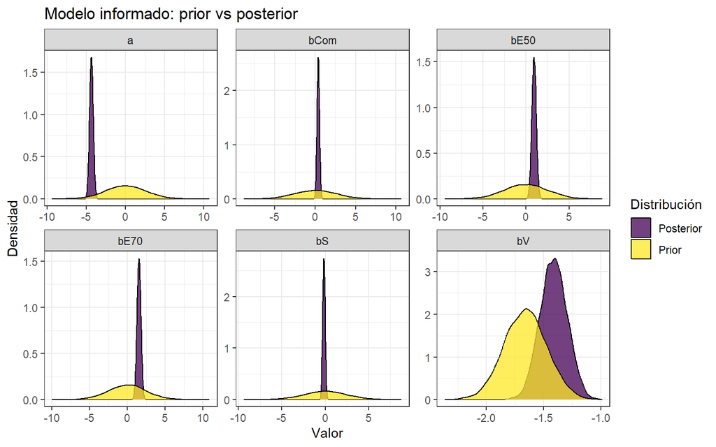

```r
posterior_informado <- as_tibble(samp_informado) %>%
    dplyr::select(a, bV, bE50, bE70, bS, bCom) %>%
    mutate(distribucion = "Posterior")

  prior_informado <- tibble(
    a  = rnorm(N_samp, 0, 2.5),
    bV = rnorm(N_samp, prior_mu_V_informado, prior_sd_V_informado),
    bE50 = rnorm(N_samp, 0, 2.5),
    bE70 = rnorm(N_samp, 0, 2.5),
    bS = rnorm(N_samp, 0, 2.5),
    bCom = rnorm(N_samp, 0, 2.5),
    distribucion = "Prior"
  )

  bind_rows(posterior_informado, prior_informado) %>%
    pivot_longer(
      cols = -distribucion,
      names_to = "variable",
      values_to = "value"
    ) %>%
    ggplot(aes(x = value, fill = distribucion)) +
    geom_density(alpha = 0.75) +
    theme_bw() +
    facet_wrap(variable ~ ., scales = "free") +
    labs(
      x = "Valor",
      y = "Densidad",
      fill = "Distribuci\u00f3n",
      title = "Modelo informado: prior vs posterior"
    ) +
    scale_fill_viridis_d()
```

```r
# ---- Guardar muestras y MAP para pasos siguientes ----
# El modelo débil es el de referencia; el informado se compara en paso 6.

beta_MAP    <- coef(modelo_quap_debil)
# Para WAIC (paso 7) necesitamos la matriz de diseño completa via MASS;
# quap guarda internamente lo necesario para rethinking::WAIC.

N_samp_sens <- N_samp   # alias para paso 6
```

# PASO 3 — Estratificación Beta-Binomial por tiempo desde vacunación

```r
  # Objetivo:
  #   Estimar la tasa posterior de hospitalizacion en cada grupo temporal y
  #   compararla contra la tasa posterior del grupo no vacunado.
  #
  # Modelo:
  #   Si en un grupo observamos:
  #       y = cantidad de hospitalizaciones
  #       n = cantidad de personas
  #
  #   y usamos un prior:
  #       theta ~ Beta(alpha, beta)
  #
  #   entonces, por conjugacion Beta-Binomial:
  #       theta | y, n ~ Beta(alpha + y, beta + n - y)
  #
  # Efectividad vacunal por simulacion:
  #       VE = 1 - theta_grupo / theta_no_vacunadas
  #
  # Priors pedidos por la guia:
  #   Beta(1,1): peso efectivo alpha + beta = 2 observaciones.
  #   Beta(2,8): peso efectivo alpha + beta = 10 observaciones,
  #              centrado en una tasa baja de hospitalizacion.
  #
  # Nota sobre "No vacunada":
  #   Los bins temporales vacunados son solo:
  #       0-90, 91-180, 181-270, 271-365
  #   "No vacunada" no es un bin temporal: se conserva como referencia/control.
  #   Para esa fila, VE se calcula contra si misma y por eso queda en 0.

  N_sim <- 10000

  priors <- tibble::tribble(
    ~prior,       ~alpha_prior, ~beta_prior, ~peso_efectivo,
    "Beta(1,1)",             1,           1,              2,
    "Beta(2,8)",             2,           8,             10
  )

  # Identificamos el grupo no vacunado desde la variable vacunada,
  # no desde el texto del nivel, para evitar depender del nombre exacto.
  idx_nv <- df$vacunada == 0

  y_nv <- sum(df$hospitalizada[idx_nv])
  nv_total <- sum(idx_nv)

  bin_no_vacunada <- unique(as.character(df$bin_tiempo[idx_nv]))

  if (length(bin_no_vacunada) != 1) {
    stop("Se esperaba un unico nivel de bin_tiempo para las personas no vacunadas.")
  }

  tabla_VE_tiempo <- purrr::map_dfr(seq_len(nrow(priors)), function(i) {
    alpha_prior <- priors$alpha_prior[i]
    beta_prior  <- priors$beta_prior[i]

    purrr::map_dfr(niveles_exposicion_tiempo, function(b) {
      idx_g <- as.character(df$bin_tiempo) == b

      y_g <- sum(df$hospitalizada[idx_g])
      n_g <- sum(idx_g)

      # Posterior de la tasa de hospitalizacion del grupo actual.
      theta_g_s <- rbeta(
        N_sim,
        shape1 = alpha_prior + y_g,
        shape2 = beta_prior + n_g - y_g
      )

      # Posterior de la tasa de hospitalizacion del grupo no vacunado.
      #
      # Si el grupo actual ES "No vacunada", usamos la misma muestra posterior.
      # Asi VE = 1 - theta_NV / theta_NV = 0 exactamente.
      # Esto deja esa fila como referencia clara en la tabla.
      if (b == bin_no_vacunada) {
        theta_NV_s <- theta_g_s
      } else {
        theta_NV_s <- rbeta(
          N_sim,
          shape1 = alpha_prior + y_nv,
          shape2 = beta_prior + nv_total - y_nv
        )
      }

      # Efectividad vacunal bayesiana por muestra posterior.
      #
      # VE > 0: el grupo tiene menor tasa que no vacunadas.
      # VE = 0: el grupo tiene tasa igual a no vacunadas.
      # VE < 0: el grupo tiene mayor tasa que no vacunadas.
      VE_bb <- 1 - theta_g_s / theta_NV_s

      # HPDI 95% usando la funcion del paquete rethinking.
      # Su implementacion devuelve un vector con nombres:
      #   lower, upper
      hpdi_ve <- HPDI(VE_bb, prob = 0.95)

      tibble::tibble(
        prior = priors$prior[i],
        peso_efectivo = priors$peso_efectivo[i],
        bin_tiempo = b,

        n = n_g,
        hospitalizadas = y_g,
        tasa_obs = ifelse(n_g > 0, y_g / n_g, NA_real_),
        tasa_obs_no_vacunadas = y_nv / nv_total,

        VE_mediana = stats::median(VE_bb),
        VE_hpdi_inf = as.numeric(hpdi_ve[1]),
        VE_hpdi_sup = as.numeric(hpdi_ve[2])
      )
    })
  })

  tabla_VE_tiempo
```

| prior | peso_efectivo | bin_tiempo | n | hospitalizadas | tasa_obs | tasa_obs_no_vacunadas | VE_mediana | VE_hpdi_inf | VE_hpdi_sup |
| --- | --- | --- | --- | --- | --- | --- | --- | --- | --- |
| Beta(1,1) | 2 | No vacunada | 4336 | 141 | 0.032518450 | 0.03251845 | 0.0000000 | 0.0000000 | 0.0000000 |
| Beta(1,1) | 2 | 0-90 | 622 | 2 | 0.003215434 | 0.03251845 | 0.8696942 | 0.6812306 | 0.9811222 |
| Beta(1,1) | 2 | 91-180 | 1688 | 16 | 0.009478673 | 0.03251845 | 0.6977428 | 0.5376490 | 0.8383891 |
| Beta(1,1) | 2 | 181-270 | 1921 | 28 | 0.014575742 | 0.03251845 | 0.5432976 | 0.3565819 | 0.7195700 |
| Beta(1,1) | 2 | 271-365 | 1667 | 28 | 0.016796641 | 0.03251845 | 0.4736697 | 0.2461188 | 0.6590640 |
| Beta(2,8) | 10 | No vacunada | 4336 | 141 | 0.032518450 | 0.03251845 | 0.0000000 | 0.0000000 | 0.0000000 |
| Beta(2,8) | 10 | 0-90 | 622 | 2 | 0.003215434 | 0.03251845 | 0.8251492 | 0.6145317 | 0.9636218 |
| Beta(2,8) | 10 | 91-180 | 1688 | 16 | 0.009478673 | 0.03251845 | 0.6835376 | 0.5183580 | 0.8275487 |
| Beta(2,8) | 10 | 181-270 | 1921 | 28 | 0.014575742 | 0.03251845 | 0.5311014 | 0.3316521 | 0.6982244 |
| Beta(2,8) | 10 | 271-365 | 1667 | 28 | 0.016796641 | 0.03251845 | 0.4600595 | 0.2381482 | 0.6539956 |

Estas VE por bin comparan descriptiva y exploratoriamente cada grupo vacunado contra personas no vacunadas. No son una estimación causal pura de waning: `No vacunada` es la referencia, no un quinto bin temporal.

# PASO 4 — Estratificación edad sola y cruce edad × tiempo

```r
# Crear grupos de edad

df <- df %>%
  mutate(
    grupo_edad = cut(
      edad,
      breaks = c(17, 49, 64, Inf),
      labels = c("18-49", "50-64", "65+")
    )
  )
```

Nota: estos cortes (`18-49`, `50-64`, `65+`) siguen la guía del análisis estratificado y son distintos de `edad_cat` (`18-49`, `50-69`, `70+`), que pertenece al modelo oficial del Paso 1.

```r
# ---- 4a: Solo edad (replicar homogeneidad del IICA) ----
# Para la estratificación por edad, vacunados vs no vacunados DENTRO del mismo
# grupo de edad es la comparación correcta (los no vacunados de cada grupo
# son el denominador natural).

cat("### 4a: VE por grupo de edad\n\n")
```

### 4a: VE por grupo de edad

```r
grupos_edad <- c("18-49", "50-64", "65+")

tabla_VE_edad <- map_dfr(grupos_edad, function(ge) {
  sub <- df %>% filter(grupo_edad == ge)

  fila_V  <- sub %>% filter(vacunada == 1) %>%
    summarise(hosp = sum(hospitalizada), total = n())
  fila_NV <- sub %>% filter(vacunada == 0) %>%
    summarise(hosp = sum(hospitalizada), total = n())

  theta_V_s  <- rbeta(N_sim, 1 + fila_V$hosp,  1 + fila_V$total  - fila_V$hosp)
  theta_NV_s <- rbeta(N_sim, 1 + fila_NV$hosp, 1 + fila_NV$total - fila_NV$hosp)

  VE_bb <- 1 - theta_V_s / theta_NV_s
  hp    <- as.numeric(HPDI(VE_bb, prob = 0.95))

  data.frame(
    grupo_edad = ge,
    n_V  = fila_V$total, n_NV = fila_NV$total,
    VE_mediana = as.numeric(median(VE_bb)),
    HPDI_lo = hp[1], HPDI_hi = hp[2]
  )
})

tabla_VE_edad %>%
  mutate(across(c(VE_mediana, HPDI_lo, HPDI_hi), ~ round(.x * 100, 1))) %>%
  knitr::kable()
```

| grupo_edad | n_V | n_NV | VE_mediana | HPDI_lo | HPDI_hi |
| --- | --- | --- | --- | --- | --- |
| 18-49 | 1036 | 1399 | 87.7 | 62.3 | 99.6 |
| 50-64 | 1629 | 1406 | 69.5 | 48.2 | 85.4 |
| 65+ | 3233 | 1531 | 66.4 | 54.7 | 76.4 |

```r
cat("\n\nLa estratificación por edad sola no contradice fuertemente la homogeneidad reportada por el análisis principal: los intervalos son amplios y se superponen. El grupo `18-49` muestra una VE puntual más alta, pero esa lectura es frágil por la baja cantidad de eventos.\n")
```

La estratificación por edad sola no contradice fuertemente la homogeneidad reportada por el análisis principal: los intervalos son amplios y se superponen. El grupo `18-49` muestra una VE puntual más alta, pero esa lectura es frágil por la baja cantidad de eventos.

```r
# ---- 4b: Grilla 3 × 4 edad × tiempo ----

cat("### 4b: Diagnóstico crudo antes de la grilla\n\n")
```

### 4b: Diagnóstico crudo antes de la grilla

```r
cat("La edad puede estar asociada al momento de vacunación. Por eso cruzamos edad × tiempo: la comparación por edad sola puede mezclar grupos con composiciones temporales distintas.\n\n")
```

La edad puede estar asociada al momento de vacunación. Por eso cruzamos edad × tiempo: la comparación por edad sola puede mezclar grupos con composiciones temporales distintas.

```r
cat("Los no vacunados no tienen tiempo desde vacunación: se usan como referencia basal dentro de cada grupo etario, no como quinto bin temporal.\n\n")
```

Los no vacunados no tienen tiempo desde vacunación: se usan como referencia basal dentro de cada grupo etario, no como quinto bin temporal.

```r
diagnostico_vacunados_edad_tiempo <- df %>%
  filter(vacunada == 1) %>%
  count(grupo_edad, bin_tiempo, name = "n_V") %>%
  tidyr::complete(
    grupo_edad = factor(grupos_edad, levels = grupos_edad),
    bin_tiempo = factor(bins_vacunados, levels = bins_vacunados),
    fill = list(n_V = 0)
  ) %>%
  left_join(
    df %>%
      filter(vacunada == 1) %>%
      group_by(grupo_edad, bin_tiempo) %>%
      summarise(hosp_V = sum(hospitalizada), .groups = "drop"),
    by = c("grupo_edad", "bin_tiempo")
  ) %>%
  mutate(
    hosp_V = replace_na(hosp_V, 0),
    riesgo_obs_V = ifelse(n_V > 0, round(100 * hosp_V / n_V, 2), NA_real_)
  )

cat("Vacunados por grupo de edad × bin temporal: conteos, eventos y proporciones observadas de hospitalización.\n\n")
```

Vacunados por grupo de edad × bin temporal: conteos, eventos y proporciones observadas de hospitalización.

```r
diagnostico_vacunados_edad_tiempo %>%
  pivot_wider(
    id_cols = grupo_edad,
    names_from = bin_tiempo,
    values_from = c(n_V, hosp_V, riesgo_obs_V),
    values_fill = list(n_V = 0, hosp_V = 0)
  ) %>%
  knitr::kable()
```

| grupo_edad | n_V_0-90 | n_V_91-180 | n_V_181-270 | n_V_271-365 | hosp_V_0-90 | hosp_V_91-180 | hosp_V_181-270 | hosp_V_271-365 | riesgo_obs_V_0-90 | riesgo_obs_V_91-180 | riesgo_obs_V_181-270 | riesgo_obs_V_271-365 |
| --- | --- | --- | --- | --- | --- | --- | --- | --- | --- | --- | --- | --- |
| 18-49 | 407 | 379 | 250 | 0 | 1 | 0 | 0 | 0 | 0.25 | 0.00 | 0.00 | NA |
| 50-64 | 149 | 491 | 480 | 509 | 1 | 4 | 5 | 3 | 0.67 | 0.81 | 1.04 | 0.59 |
| 65+ | 66 | 818 | 1191 | 1158 | 0 | 12 | 23 | 25 | 0.00 | 1.47 | 1.93 | 2.16 |

```r
cat("\n\nHospitalizaciones entre no vacunados por grupo de edad, usadas como referencia basal dentro de cada grupo etario.\n\n")
```

Hospitalizaciones entre no vacunados por grupo de edad, usadas como referencia basal dentro de cada grupo etario.

```r
df %>%
  filter(vacunada == 0) %>%
  group_by(grupo_edad) %>%
  summarise(hosp = sum(hospitalizada), total = n(),
            riesgo_obs = round(100 * hosp / total, 2), .groups = "drop") %>%
  knitr::kable()
```

| grupo_edad | hosp | total | riesgo_obs |
| --- | --- | --- | --- |
| 18-49 | 18 | 1399 | 1.29 |
| 50-64 | 38 | 1406 | 2.70 |
| 65+ | 85 | 1531 | 5.55 |

```r
# ---- Grilla propiamente dicha ----
# Denominador correcto: no vacunados del MISMO grupo de edad.
# El riesgo/proporción observado en no vacunados se repite como referencia
# basal por edad en los cuatro bins de vacunados.
# Esto es una limitación del diseño Beta-Binomial simple: idealmente se
# usarían tasas persona-tiempo, pero con los datos disponibles es la mejor
# aproximación posible para este ejercicio didáctico.

cat("### Grilla 3 × 4 edad × tiempo\n\n")
```

### Grilla 3 × 4 edad × tiempo

```r
cat("La referencia no vacunada (`n_NV`, `hosp_NV` y su proporción observada) es basal por edad y se repite para los cuatro bins temporales de vacunados.\n\n")
```

La referencia no vacunada (`n_NV`, `hosp_NV` y su proporción observada) es basal por edad y se repite para los cuatro bins temporales de vacunados.

```r
cat("Como apoyo interpretativo, marcamos celdas inestables cuando `n_V == 0 | hosp_V < 3 | n_V < 30 | (HPDI_hi - HPDI_lo) > 0.75`.\n\n")
```

Como apoyo interpretativo, marcamos celdas inestables cuando `n_V == 0 | hosp_V < 3 | n_V < 30 | (HPDI_hi - HPDI_lo) > 0.75`.

```r
tabla_cruce <- map_dfr(grupos_edad, function(ge) {
  nv_edad <- df %>%
    filter(grupo_edad == ge, vacunada == 0) %>%
    summarise(hosp = sum(hospitalizada), total = n())

  map_dfr(bins_vacunados, function(b) {
    fila_V <- df %>%
      filter(grupo_edad == ge, vacunada == 1, bin_tiempo == b) %>%
      summarise(hosp = sum(hospitalizada), total = n())

    if (fila_V$total == 0 | nv_edad$total == 0) {
      return(data.frame(grupo_edad = ge, bin = b,
                        n_V = fila_V$total, n_NV = nv_edad$total,
                        hosp_V = fila_V$hosp, hosp_NV = nv_edad$hosp,
                        VE_mediana = NA_real_, HPDI_lo = NA_real_, HPDI_hi = NA_real_,
                        celda_inestable = TRUE,
                        motivo_inestabilidad = "n_V = 0"))
    }

    theta_V_s  <- rbeta(N_sim, 1 + fila_V$hosp,  1 + fila_V$total  - fila_V$hosp)
    theta_NV_s <- rbeta(N_sim, 1 + nv_edad$hosp, 1 + nv_edad$total - nv_edad$hosp)

    VE_bb <- 1 - theta_V_s / theta_NV_s
    hp    <- as.numeric(HPDI(VE_bb, prob = 0.95))

    celda_inestable <- fila_V$total == 0 |
      fila_V$hosp < 3 |
      fila_V$total < 30 |
      (hp[2] - hp[1]) > 0.75

    motivos <- c(
      if (fila_V$total == 0) "n_V = 0",
      if (fila_V$hosp < 3) "hosp_V < 3",
      if (fila_V$total < 30) "n_V < 30",
      if ((hp[2] - hp[1]) > 0.75) "HPDI ancho"
    )

    data.frame(
      grupo_edad = ge, bin = b,
      n_V  = fila_V$total, n_NV = nv_edad$total,
      hosp_V = fila_V$hosp, hosp_NV = nv_edad$hosp,
      VE_mediana = as.numeric(median(VE_bb)),
      HPDI_lo = hp[1], HPDI_hi = hp[2],
      celda_inestable = celda_inestable,
      motivo_inestabilidad = ifelse(celda_inestable, paste(motivos, collapse = "; "), "ok")
    )
  })
})

stopifnot(nrow(tabla_cruce) == 12)

cat("Grilla con conteos crudos, proporciones observadas y VE bayesiana.\n\n")
```

Grilla con conteos crudos, proporciones observadas y VE bayesiana.

```r
tabla_cruce %>%
  mutate(
    riesgo_obs_V  = ifelse(n_V  > 0, round(100 * hosp_V  / n_V,  2), NA_real_),
    riesgo_obs_NV = ifelse(n_NV > 0, round(100 * hosp_NV / n_NV, 2), NA_real_),
    across(c(VE_mediana, HPDI_lo, HPDI_hi),
           ~ ifelse(is.na(.x), NA_real_, round(.x * 100, 1))),
    nota = ifelse(celda_inestable,
                  paste("inestable:", motivo_inestabilidad),
                  "ok")
  ) %>%
  knitr::kable()
```

| grupo_edad | bin | n_V | n_NV | hosp_V | hosp_NV | VE_mediana | HPDI_lo | HPDI_hi | celda_inestable | motivo_inestabilidad | riesgo_obs_V | riesgo_obs_NV | nota |
| --- | --- | --- | --- | --- | --- | --- | --- | --- | --- | --- | --- | --- | --- |
| 18-49 | 0-90 | 407 | 1399 | 1 | 18 | 69.5 | 4.6 | 98.8 | TRUE | hosp_V < 3; HPDI ancho | 0.25 | 1.29 | inestable: hosp_V < 3; HPDI ancho |
| 18-49 | 91-180 | 379 | 1399 | 0 | 18 | 86.5 | 38.1 | 100.0 | TRUE | hosp_V < 3 | 0.00 | 1.29 | inestable: hosp_V < 3 |
| 18-49 | 181-270 | 250 | 1399 | 0 | 18 | 79.0 | 3.5 | 100.0 | TRUE | hosp_V < 3; HPDI ancho | 0.00 | 1.29 | inestable: hosp_V < 3; HPDI ancho |
| 18-49 | 271-365 | 0 | 1399 | 0 | 18 | NA | NA | NA | TRUE | n_V = 0 | NA | 1.29 | inestable: n_V = 0 |
| 50-64 | 0-90 | 149 | 1406 | 1 | 38 | 59.2 | -19.5 | 98.6 | TRUE | hosp_V < 3; HPDI ancho | 0.67 | 2.70 | inestable: hosp_V < 3; HPDI ancho |
| 50-64 | 91-180 | 491 | 1406 | 4 | 38 | 65.6 | 26.2 | 91.2 | FALSE | ok | 0.81 | 2.70 | ok |
| 50-64 | 181-270 | 480 | 1406 | 5 | 38 | 57.0 | 14.1 | 87.6 | FALSE | ok | 1.04 | 2.70 | ok |
| 50-64 | 271-365 | 509 | 1406 | 3 | 38 | 73.7 | 40.3 | 95.1 | FALSE | ok | 0.59 | 2.70 | ok |
| 65+ | 0-90 | 66 | 1531 | 0 | 85 | 81.9 | 20.5 | 100.0 | TRUE | hosp_V < 3; HPDI ancho | 0.00 | 5.55 | inestable: hosp_V < 3; HPDI ancho |
| 65+ | 91-180 | 818 | 1531 | 12 | 85 | 72.5 | 53.9 | 86.4 | FALSE | ok | 1.47 | 5.55 | ok |
| 65+ | 181-270 | 1191 | 1531 | 23 | 85 | 64.4 | 47.7 | 79.7 | FALSE | ok | 1.93 | 5.55 | ok |
| 65+ | 271-365 | 1158 | 1531 | 25 | 85 | 60.4 | 41.9 | 76.7 | FALSE | ok | 2.16 | 5.55 | ok |

```r
# Diagnóstico de Simpson invertida

cat("### Diagnóstico de Simpson invertida\n\n")
```

### Diagnóstico de Simpson invertida

```r
cat("Los grupos etarios tienen distinta distribución de tiempo desde vacunación. En los vacunados, `18-49` no tiene observaciones en `271-365`, mientras que `50-64` y `65+` concentran cerca de un tercio de sus vacunados en el bin tardío.\n\n")
```

Los grupos etarios tienen distinta distribución de tiempo desde vacunación. En los vacunados, `18-49` no tiene observaciones en `271-365`, mientras que `50-64` y `65+` concentran cerca de un tercio de sus vacunados en el bin tardío.

```r
cat("El patrón sugiere mezcla edad-tiempo/calendario: los adultos mayores parecen más representados en períodos más alejados de la vacunación, y una comparación agregada por edad puede mezclar riesgo basal etario con tiempo desde vacunación.\n\n")
```

El patrón sugiere mezcla edad-tiempo/calendario: los adultos mayores parecen más representados en períodos más alejados de la vacunación, y una comparación agregada por edad puede mezclar riesgo basal etario con tiempo desde vacunación.

```r
cat("Esto no alcanza para afirmar una Simpson invertida estricta. Seis de las doce celdas de la grilla son inestables (`18-49 × 0-90`, `18-49 × 91-180`, `18-49 × 181-270`, `18-49 × 271-365`, `50-64 × 0-90`, `65+ × 0-90`), por lo que la lectura debe quedar como evidencia exploratoria de composición edad-tiempo/calendario, no como demostración causal cerrada.\n\n")
```

Esto no alcanza para afirmar una Simpson invertida estricta. Seis de las doce celdas de la grilla son inestables (`18-49 × 0-90`, `18-49 × 91-180`, `18-49 × 181-270`, `18-49 × 271-365`, `50-64 × 0-90`, `65+ × 0-90`), por lo que la lectura debe quedar como evidencia exploratoria de composición edad-tiempo/calendario, no como demostración causal cerrada.

```r
cat("Distribución de días desde vacunación por grupo de edad:\n\n")
```

Distribución de días desde vacunación por grupo de edad:

```r
df %>%
  filter(vacunada == 1) %>%
  group_by(grupo_edad) %>%
  summarise(
    dias_mediana = median(dias_desde_vacunacion),
    dias_media   = mean(dias_desde_vacunacion),
    prop_tardio  = mean(dias_desde_vacunacion > 270)
  ) %>%
  knitr::kable()
```

| grupo_edad | dias_mediana | dias_media | prop_tardio |
| --- | --- | --- | --- |
| 18-49 | 117 | 118.0058 | 0.0000000 |
| 50-64 | 212 | 212.8036 | 0.3124616 |
| 65+ | 237 | 235.5710 | 0.3581813 |

**Limitación**: no tenemos fecha de hospitalización para no vacunados. Por eso no podemos construir controles no vacunados alineados por calendario o por bin temporal; las comparaciones no separan causalmente waning de composición por edad, tiempo desde vacunación y calendario.

# PASO 5 — DAG causal

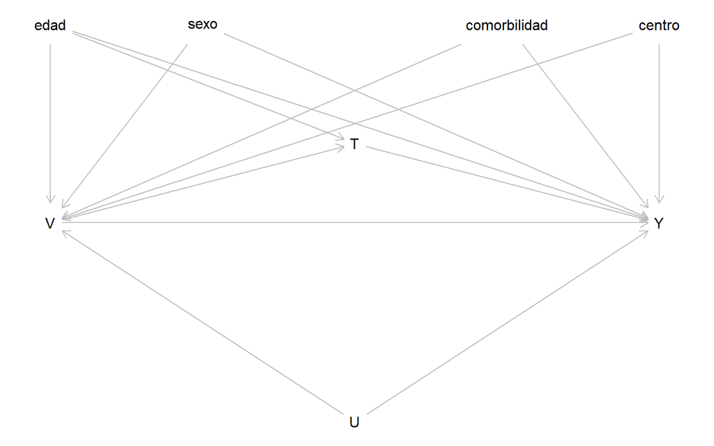

```r
dag_velmyra <- dagitty('dag {
    U [unobserved]
    V  -> Y
    V  -> T
    T  -> Y
    U  -> V
    U  -> Y
    edad        -> V
    edad        -> T
    edad        -> Y
    sexo        -> V
    sexo        -> Y
    comorbilidad -> V
    comorbilidad -> Y
    centro      -> V
    centro      -> Y
  }')

# Coordenadas para el layout del grafo
coordinates(dag_velmyra) <- list(
  x = c(V = 0, T = 2, Y = 4, U = 2,
          edad = 0, sexo = 1, comorbilidad = 3, centro = 4),
  y = c(V = 0, T = -0.8, Y = 0, U = 2,
          edad = -2, sexo = -2, comorbilidad = -2, centro = -2)
)

# Gráfico base con dagitty
plot(dag_velmyra)
```

```r
cat("\n\nConjuntos de ajuste identificados por `dagitty` para `V -> Y`:\n\n")
```

Conjuntos de ajuste identificados por `dagitty` para `V -> Y`:

```r
ajustes_VY <- capture.output(
  adjustmentSets(dag_velmyra, exposure = "V", outcome = "Y")
)

if (length(ajustes_VY) == 0) {
  tabla_ajustes <- tibble::tibble(
    Resultado = "No hay un conjunto de ajuste medido suficiente bajo este DAG."
  )
} else {
  tabla_ajustes <- tibble::tibble(Resultado = ajustes_VY)
}

knitr::kable(tabla_ajustes)
```

| Resultado |
| --- |
| No hay un conjunto de ajuste medido suficiente bajo este DAG. |

```r
cat("\n\nEl DAG se lee en dos niveles. Para la pregunta causal principal, `V -> Y` representa el efecto binario de vacunarse sobre hospitalización. Las covariables medidas (edad, sexo, comorbilidad y centro) pueden afectar tanto la probabilidad de vacunarse como el riesgo de hospitalización, por lo que forman caminos de confusión del tipo `C -> V` y `C -> Y`.\n\n")
```

El DAG se lee en dos niveles. Para la pregunta causal principal, `V -> Y` representa el efecto binario de vacunarse sobre hospitalización. Las covariables medidas (edad, sexo, comorbilidad y centro) pueden afectar tanto la probabilidad de vacunarse como el riesgo de hospitalización, por lo que forman caminos de confusión del tipo `C -> V` y `C -> Y`.

```r
cat("En términos de los patrones básicos del DAG, las covariables medidas y `U` forman bifurcaciones o forks de confusión; `V -> T -> Y` es una cadena o pipe asociada al mecanismo temporal; y no se introduce ningún collider como variable de ajuste.\n\n")
```

En términos de los patrones básicos del DAG, las covariables medidas y `U` forman bifurcaciones o forks de confusión; `V -> T -> Y` es una cadena o pipe asociada al mecanismo temporal; y no se introduce ningún collider como variable de ajuste.

```r
cat("El nodo `U` representa estado de salud previo, acceso al sistema u otros factores no observados vinculados al sesgo del vacunado sano. Este nodo abre el camino de puerta trasera `V <- U -> Y`. Como `U` no está observado, el ajuste por edad, sexo, comorbilidad y centro reduce la confusión observable, pero no identifica por completo el efecto causal de `V` sobre `Y`.\n\n")
```

El nodo `U` representa estado de salud previo, acceso al sistema u otros factores no observados vinculados al sesgo del vacunado sano. Este nodo abre el camino de puerta trasera `V <- U -> Y`. Como `U` no está observado, el ajuste por edad, sexo, comorbilidad y centro reduce la confusión observable, pero no identifica por completo el efecto causal de `V` sobre `Y`.

```r
cat("Por eso, la ausencia de un conjunto de ajuste medido suficiente no debe leerse como un error del DAG, sino como la razón causal para realizar el análisis de sensibilidad del Paso 6. Ese paso cuantifica cuánto podría desplazarse el efecto observado si existe confusión residual por `U`.\n\n")
```

Por eso, la ausencia de un conjunto de ajuste medido suficiente no debe leerse como un error del DAG, sino como la razón causal para realizar el análisis de sensibilidad del Paso 6. Ese paso cuantifica cuánto podría desplazarse el efecto observado si existe confusión residual por `U`.

```r
cat("El nodo `T` representa `dias_desde_vacunacion`. No es un confusor basal del contraste vacunada vs no vacunada: es una variable temporal derivada de la vacunación. Por eso aparece como descendiente de `V`, útil para razonar sobre waning y composición edad-tiempo/calendario, pero no se ajusta como si fuera una covariable pretratamiento en el efecto binario de vacunarse.\n\n")
```

El nodo `T` representa `dias_desde_vacunacion`. No es un confusor basal del contraste vacunada vs no vacunada: es una variable temporal derivada de la vacunación. Por eso aparece como descendiente de `V`, útil para razonar sobre waning y composición edad-tiempo/calendario, pero no se ajusta como si fuera una covariable pretratamiento en el efecto binario de vacunarse.

```r
cat("La flecha `edad -> T` resume la priorización y el calendario de vacunación por edad: distintos grupos etarios pueden quedar con distribuciones diferentes de días desde vacunación. Esta parte del DAG conecta con los análisis estratificados de los Pasos 3 y 4, no con una identificación causal plena del waning.\n\n")
```

La flecha `edad -> T` resume la priorización y el calendario de vacunación por edad: distintos grupos etarios pueden quedar con distribuciones diferentes de días desde vacunación. Esta parte del DAG conecta con los análisis estratificados de los Pasos 3 y 4, no con una identificación causal plena del waning.

```r
cat("Dirección del sesgo: si `U` mejora la salud basal y también aumenta la probabilidad de vacunarse, la VE observada queda inflada. En ese caso, el efecto causal corregido sería menos protector que el estimado crudo o ajustado solo por covariables medidas.\n")
```

Dirección del sesgo: si `U` mejora la salud basal y también aumenta la probabilidad de vacunarse, la VE observada queda inflada. En ese caso, el efecto causal corregido sería menos protector que el estimado crudo o ajustado solo por covariables medidas.

# PASO 6 — Sensibilidad a confusor no medido (vía paramétrica bayesiana)

```r
# β_causal = β_observado - δ
# δ ~ N(mu_delta, sigma_delta²)
# Por composición gaussiana:
#   β_causal ~ N(β_obs - mu_delta, sigma_V² + sigma_delta²)
# Con esta parametrización, δ < 0 representa sesgo del vacunado sano:
# β_obs queda más negativo/protector y β_causal = β_obs - δ vuelve el efecto
# menos protector.

beta_obs   <- as.numeric(coef(modelo_quap_debil)["bV"])
sigma_V    <- as.numeric(sqrt(vcov(modelo_quap_debil)["bV", "bV"]))
OR_obs_val <- as.numeric(exp(coef(modelo_quap_debil)["bV"]))

# Tres priors sobre δ (cuánto sesga U al coeficiente de la vacuna)
# Sesgo del vacunado sano -> δ < 0 (infla la protección observada).

priors_delta <- list(
  debil    = list(mu = -0.10, sd = 0.10, label = "Débil    (σ=0.10): confusor pequeño"),
  moderado = list(mu = -0.20, sd = 0.20, label = "Moderado (σ=0.20): confusor moderado"),
  agresivo = list(mu = -0.40, sd = 0.30, label = "Agresivo (σ=0.30): sesgo vacunado sano fuerte")
)

cat(sprintf("`beta_observado` (MAP): %.3f\n\n", beta_obs))
```

`beta_observado` (MAP): -1.251

```r
cat(sprintf("Sigma posterior: %.3f\n\n", sigma_V))
```

Sigma posterior: 0.148

```r
cat("Contraste afectado por `U`: vacunados vs no vacunados.\n\n")
```

Contraste afectado por `U`: vacunados vs no vacunados.

```r
cat("Este es un análisis de desplazamiento en escala log-OR: `beta_causal = beta_obs - delta`. No modela explícitamente la prevalencia de `U` ni su fuerza de asociación con `V` e `Y`.\n\n")
```

Este es un análisis de desplazamiento en escala log-OR: `beta_causal = beta_obs - delta`. No modela explícitamente la prevalencia de `U` ni su fuerza de asociación con `V` e `Y`.

```r
tabla_priors_delta <- tibble::tibble(
  escenario = names(priors_delta),
  mu_delta = purrr::map_dbl(priors_delta, "mu"),
  sd_delta = purrr::map_dbl(priors_delta, "sd"),
  exp_mu_delta = exp(mu_delta)
)

cat("Priors usados para `delta` e interpretación como factor multiplicativo `exp(mu_delta)` sobre el OR observado:\n\n")
```

Priors usados para `delta` e interpretación como factor multiplicativo `exp(mu_delta)` sobre el OR observado:

```r
tabla_priors_delta %>%
  mutate(
    mu_delta = round(mu_delta, 2),
    sd_delta = round(sd_delta, 2),
    exp_mu_delta = round(exp_mu_delta, 2)
  ) %>%
  knitr::kable()
```

| escenario | mu_delta | sd_delta | exp_mu_delta |
| --- | --- | --- | --- |
| debil | -0.1 | 0.1 | 0.90 |
| moderado | -0.2 | 0.2 | 0.82 |
| agresivo | -0.4 | 0.3 | 0.67 |

```r
resultados_sens <- map_dfr(names(priors_delta), function(nm) {
  pd <- priors_delta[[nm]]

  # Muestrear β_causal por composición gaussiana:
  # β_causal = β_obs_s - δ_s, donde β_obs_s ~ posterior quap y δ_s ~ prior del sesgo

  beta_obs_s     <- samp_debil$bV                      # muestras de la posterior quap
  delta_s        <- rnorm(N_samp, pd$mu, pd$sd)
  beta_causal_s  <- beta_obs_s - delta_s
  VE_causal_s    <- 1 - exp(beta_causal_s)

  hp <- as.numeric(HPDI(VE_causal_s, prob = 0.95))

  data.frame(
    prior    = nm,
    label    = pd$label,
    mu_delta = pd$mu,
    sd_delta = pd$sd,
    VE_mediana = as.numeric(median(VE_causal_s)),
    HPDI_lo    = hp[1],
    HPDI_hi    = hp[2]
  )
})

cat("\n\nVE ajustada por sensibilidad bajo estos priors:\n\n")
```

VE ajustada por sensibilidad bajo estos priors:

```r
resultados_sens %>%
  mutate(across(c(VE_mediana, HPDI_lo, HPDI_hi), ~ round(.x * 100, 1))) %>%
  dplyr::select(label, VE_mediana, HPDI_lo, HPDI_hi) %>%
  knitr::kable()
```

| label | VE_mediana | HPDI_lo | HPDI_hi |
| --- | --- | --- | --- |
| Débil (σ=0.10): confusor pequeño | 68.5 | 55.9 | 78.2 |
| Moderado (σ=0.20): confusor moderado | 65.3 | 46.0 | 80.6 |
| Agresivo (σ=0.30): sesgo vacunado sano fuerte | 57.6 | 24.1 | 80.8 |

```r
cat("\n\nNota: incluso bajo el prior agresivo, que representa un sesgo del vacunado sano fuerte, la VE ajustada por sensibilidad permanece positiva para vacunados vs no vacunados bajo estos supuestos.\n")
```

Nota: incluso bajo el prior agresivo, que representa un sesgo del vacunado sano fuerte, la VE ajustada por sensibilidad permanece positiva para vacunados vs no vacunados bajo estos supuestos.

```r
# ---- E-value (Apéndice B, opcional) ----

cat("### E-value (complemento epidemiológico, Apéndice B)\n\n")
```

### E-value (complemento epidemiológico, Apéndice B)

```r
evalue <- (1 / OR_obs_val) + sqrt((1 / OR_obs_val) * (1 / OR_obs_val - 1))
cat(sprintf("OR observado = %.3f; E-value = %.2f.\n\n", OR_obs_val, evalue))
```

OR observado = 0.286; E-value = 6.45.

```r
cat(sprintf("Interpretación: se necesitaría un `U` con RR >= %.2f para ambas relaciones (`U -> V` y `U -> Y`) para explicar el efecto observado como espurio, bajo los supuestos del E-value. Como el evento es infrecuente, usamos el OR como aproximación al RR.\n\n", evalue))
```

Interpretación: se necesitaría un `U` con RR >= 6.45 para ambas relaciones (`U -> V` y `U -> Y`) para explicar el efecto observado como espurio, bajo los supuestos del E-value. Como el evento es infrecuente, usamos el OR como aproximación al RR.

```r
cat("Esto indica que haría falta confusión fuerte para explicar el efecto observado bajo esos supuestos; no es evidencia de que esa confusión fuerte exista. El E-value es un complemento: no reemplaza la sensibilidad bayesiana anterior.\n")
```

Esto indica que haría falta confusión fuerte para explicar el efecto observado bajo esos supuestos; no es evidencia de que esa confusión fuerte exista. El E-value es un complemento: no reemplaza la sensibilidad bayesiana anterior.

# PASO 7 — Comparación de modelos con WAIC (rethinking::WAIC)

```r
# M1: modelo bayesiano simplificado del paso 2 (modelo_quap_debil):
#     vacunada + edad_cat dummies + sexo + comorbilidad, sin centro.
# M2: factor temporal único con cinco niveles:
#     No vacunada, 0-90, 91-180, 181-270, 271-365.
# "No vacunada" es la referencia conceptual. Los cuatro niveles restantes se
# codifican como indicadores categóricos, no como puntaje ordinal. M2 reemplaza
# vacunada por el factor temporal y mantiene las mismas covariables restantes.

bin_tiempo_m2 <- factor(df$bin_tiempo, levels = niveles_exposicion_tiempo)
bin_tiempo_idx_m2 <- as.integer(bin_tiempo_m2)

tabla_niveles_m2 <- tibble::tibble(
  indice = seq_along(niveles_exposicion_tiempo),
  bin_tiempo = niveles_exposicion_tiempo
)

cat("Codificación del factor temporal de M2:\n\n")
```

Codificación del factor temporal de M2:

```r
knitr::kable(tabla_niveles_m2)
```

| indice | bin_tiempo |
| --- | --- |
| 1 | No vacunada |
| 2 | 0-90 |
| 3 | 91-180 |
| 4 | 181-270 |
| 5 | 271-365 |

```r
stopifnot(identical(levels(bin_tiempo_m2), niveles_exposicion_tiempo))

dat_m2 <- list(
  hospitalizada = as.integer(df$hospitalizada),
  nivel_0_90    = as.integer(bin_tiempo_idx_m2 == match("0-90", niveles_exposicion_tiempo)),
  nivel_91_180  = as.integer(bin_tiempo_idx_m2 == match("91-180", niveles_exposicion_tiempo)),
  nivel_181_270 = as.integer(bin_tiempo_idx_m2 == match("181-270", niveles_exposicion_tiempo)),
  nivel_271_365 = as.integer(bin_tiempo_idx_m2 == match("271-365", niveles_exposicion_tiempo)),
  edad_50_69    = dat$edad_50_69,
  edad_70_plus  = dat$edad_70_plus,
  sexo          = dat$sexo,
  comorbilidad  = dat$comorbilidad
)

modelo_quap_m2 <- quap(
  alist(
    hospitalizada ~ dbinom(1, p),
    logit(p) <- a +
      bT_0_90    * nivel_0_90 +
      bT_91_180  * nivel_91_180 +
      bT_181_270 * nivel_181_270 +
      bT_271_365 * nivel_271_365 +
      bE50 * edad_50_69 +
      bE70 * edad_70_plus +
      bS * sexo +
      bCom * comorbilidad,
    a ~ dnorm(0, 2.5),
    bT_0_90    ~ dnorm(0, 2.5),
    bT_91_180  ~ dnorm(0, 2.5),
    bT_181_270 ~ dnorm(0, 2.5),
    bT_271_365 ~ dnorm(0, 2.5),
    bE50 ~ dnorm(0, 2.5),
    bE70 ~ dnorm(0, 2.5),
    bS ~ dnorm(0, 2.5),
    bCom ~ dnorm(0, 2.5)
  ),
  data = dat_m2
)

# rethinking::WAIC calcula automáticamente lppd, pWAIC y SE

waic_M1 <- rethinking::WAIC(modelo_quap_debil, n = N_samp)
waic_M2 <- rethinking::WAIC(modelo_quap_m2,    n = N_samp)

tabla_waic <- function(x) {
  if (is.atomic(x) && !is.null(names(x))) {
    return(tibble::tibble(metrica = names(x), valor = as.numeric(x)))
  }

  if (is.list(x) && !is.null(names(x))) {
    vals <- x[vapply(x, function(z) length(z) == 1 && is.numeric(z), logical(1))]
    if (length(vals) > 0) {
      return(tibble::tibble(metrica = names(vals), valor = as.numeric(unlist(vals))))
    }
  }

  tibble::tibble(resultado = capture.output(print(x)))
}

cat("\n\nM1 (agregado):\n\n")
```

M1 (agregado):

```r
tabla_waic(waic_M1) %>%
  mutate(across(where(is.numeric), ~ round(.x, 3))) %>%
  knitr::kable()
```

| metrica | valor |
| --- | --- |
| WAIC | 1973.072 |
| lppd | -980.698 |
| penalty | 5.838 |
| std_err | 105.553 |

```r
cat("M2 (niveles temporales):\n\n")
```

M2 (niveles temporales):

```r
tabla_waic(waic_M2) %>%
  mutate(across(where(is.numeric), ~ round(.x, 3))) %>%
  knitr::kable()
```

| metrica | valor |
| --- | --- |
| WAIC | 1976.999 |
| lppd | -979.841 |
| penalty | 8.658 |
| std_err | 105.560 |

```r
# Comparación directa con rethinking::compare

comp <- rethinking::compare(modelo_quap_debil, modelo_quap_m2)
cat("Comparación de modelos:\n\n")
```

Comparación de modelos:

```r
tabla_comp <- tryCatch({
  comp_df <- as.data.frame(as.matrix(comp))
  comp_df$modelo <- rownames(comp_df)
  comp_df %>% dplyr::relocate(modelo)
}, error = function(e) {
  tibble::tibble(resultado = capture.output(print(comp)))
})

tabla_comp %>%
  mutate(across(where(is.numeric), ~ round(.x, 3))) %>%
  knitr::kable()
```

|  | modelo | WAIC | SE | dWAIC | dSE | pWAIC | weight |
| --- | --- | --- | --- | --- | --- | --- | --- |
| modelo_quap_debil | modelo_quap_debil | 1973.055 | 105.484 | 0.000 | NA | 5.814 | 0.893 |
| modelo_quap_m2 | modelo_quap_m2 | 1977.308 | 105.650 | 4.253 | 3.026 | 8.835 | 0.107 |

```r
cat("Interpretación: M1 tiene menor WAIC en este render, pero la diferencia es pequeña/moderada y no decide causalidad. WAIC no descarta heterogeneidad temporal ni edad-tiempo; esa lectura queda en Pasos 3 y 4.\n\n")
```

Interpretación: M1 tiene menor WAIC en este render, pero la diferencia es pequeña/moderada y no decide causalidad. WAIC no descarta heterogeneidad temporal ni edad-tiempo; esa lectura queda en Pasos 3 y 4.

```r
cat("WAIC evalúa desempeño predictivo comparado entre M1 (`vacunada`) y M2 (factor temporal único). No valida ni refuta la grilla edad × tiempo del Paso 4.\n")
```

WAIC evalúa desempeño predictivo comparado entre M1 (`vacunada`) y M2 (factor temporal único). No valida ni refuta la grilla edad × tiempo del Paso 4.

# Respuestas operativas a las dos quejas

## Queja 1: vacunación hace aproximadamente 14 meses

Catorce meses queda fuera del soporte directo del dataset: el seguimiento observado llega hasta 365 días. Por eso `271-365` no estima directamente 14 meses; se usa como el bin tardío observado más cercano.

**Bin tardío observado, 271-365 días (Beta(1,1))**: VE mediana = 47.4%, HPDI 95% = [24.6%, 65.9%].

**Sensibilidad Beta(2,8), 271-365 días**: VE mediana = 46.0%, HPDI 95% = [23.8%, 65.4%].

**Bin pico observado, 0-90 días (Beta(1,1))**: VE mediana = 87.0%, HPDI 95% = [68.1%, 98.1%].

**Lectura bayesiana**: bajo este modelo, `P(VE_271-365 < VE_0-90 | datos) = 99.6%` y `P(VE_271-365 > 0 | datos) = 100.0%`. Esto no prueba causalmente waning, pero sí sostiene la conjetura de protección atenuada con riesgo residual.

**Respuesta operativa a la Defensoría**: la hospitalización 14 meses después de vacunarse es compatible con el riesgo residual esperado si la protección cae respecto del pico. No implica que la vacuna no haya funcionado. El reanálisis justifica evaluar un refuerzo alrededor de los 12 meses como hipótesis operativa para las autoridades sanitarias, no como una indicación clínica individual cerrada.

## Queja 2: paciente de 72 años, vacunada hace aproximadamente 9 meses

Una edad de 72 años cae en `65+`; nueve meses cae dentro del bin `181-270` días. La respuesta usa esa celda edad × tiempo, comparada contra no vacunadas del mismo grupo etario.

**Celda `65+` y `181-270` días**: mediana = 64.4%, HPDI 95% = [47.7%, 79.7%].

**Lectura bayesiana**: bajo este modelo, `P(VE > 0 | datos) = 100.0%` y `P(VE > 50% | datos) = 93.5%` para la celda `65+ × 181-270`. La evidencia posterior favorece protección sostenida en esa celda, con la incertidumbre cuantificada por el HPDI.

**Respuesta operativa a la Defensoría**: para una paciente de 72 años vacunada hace 9 meses, el reanálisis no sugiere pérdida clara de protección en su celda; sugiere protección probablemente sostenida, aunque no absoluta. Si en una actualización futura la celda `65+ × 181-270` mostrara caída marcada o HPDI compatible con protección baja/nula, entonces el refuerzo pasaría a ser la recomendación operativa natural. Con este marco, la conjetura objetiva es mantener vigilancia y considerar refuerzo por política general de duración, no porque esta celda muestre fracaso.

# Visualizaciones

## Paso 2 — Posterior bayesiano: IC/HPDI

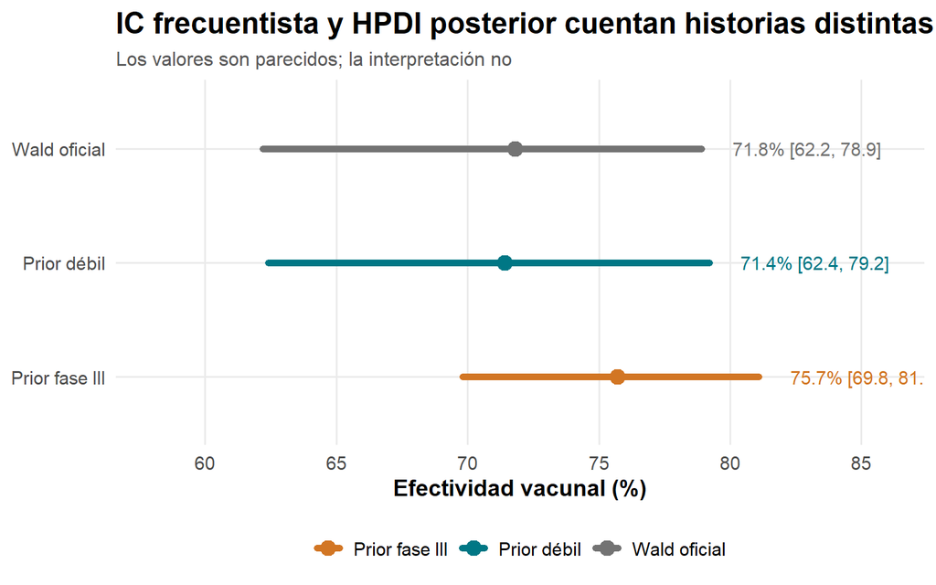

## Paso 3 — Tiempo desde vacunación

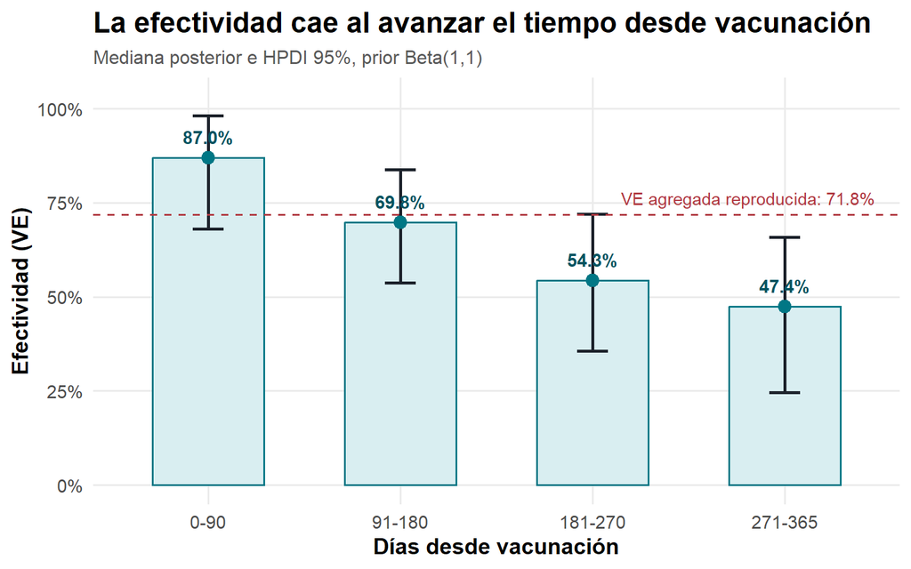

## Paso 4 — Edad × tiempo

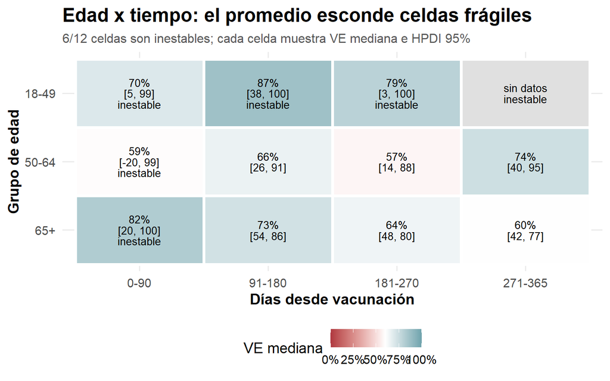

## Paso 6 — Sensibilidad a confusor no medido

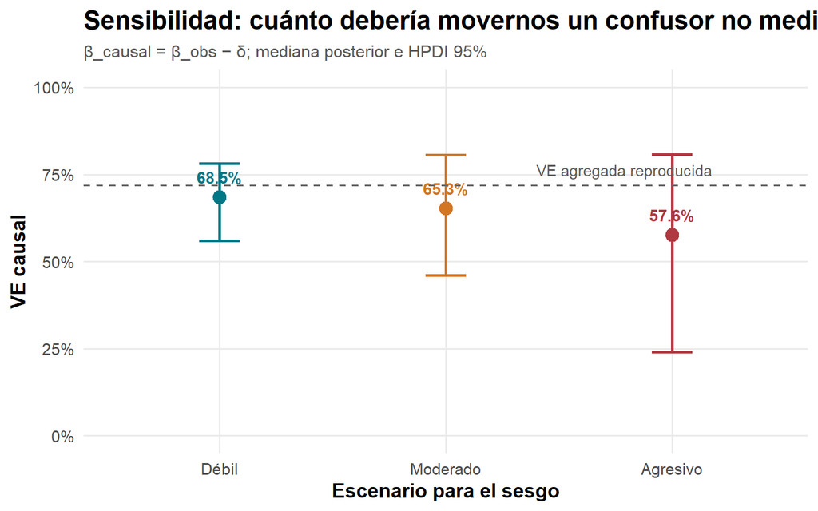

# Bonus v2: cohorte ampliada y vacunación previa

Resultados de la cohorte ampliada. La v2 se usa como actualización descriptiva y no como una nueva identificación causal.

```
## Dimensiones del dataset v2: 25000 filas x 14 columnas
```

```
## Rows: 25,000
## Columns: 14
## $ id                    <dbl> 1, 2, 3, 4, 5, 6, 7, 8, 9, 10, 11, 12, 13, 14, 1…
## $ edad                  <dbl> 53, 81, 94, 81, 88, 59, 45, 84, 62, 65, 70, 39, …
## $ sexo                  <chr> "F", "M", "F", "F", "M", "M", "M", "M", "M", "F"…
## $ comorbilidad          <dbl> 0, 1, 1, 1, 0, 0, 0, 0, 0, 0, 1, 0, 1, 1, 1, 1, …
## $ centro                <chr> "C01", "C01", "C04", "C08", "C09", "C03", "C12",…
## $ vacunacion_previa     <dbl> 1, 0, 0, 0, 1, 1, 0, 0, 1, 1, 0, 0, 0, 0, 1, 1, …
## $ vacunada              <dbl> 0, 1, 1, 1, 1, 1, 0, 1, 1, 0, 1, 0, 1, 0, 0, 1, …
## $ dias_desde_vacunacion <dbl> -1, 354, 224, 145, 271, 149, -1, 347, 314, -1, 2…
## $ mes_inclusion         <dbl> 12, 4, 3, 9, 9, 7, 9, 7, 5, 5, 6, 4, 2, 7, 4, 1,…
## $ expuesto              <dbl> 0, 0, 0, 0, 0, 0, 0, 0, 0, 0, 0, 0, 0, 0, 1, 0, …
## $ hospitalizada         <dbl> 0, 0, 0, 0, 0, 0, 0, 0, 0, 0, 0, 0, 0, 0, 0, 0, …
## $ edad_cat              <fct> 50-69, 70+, 70+, 70+, 70+, 50-69, 18-49, 70+, 50…
## $ grupo_edad            <fct> 50-64, 65+, 65+, 65+, 65+, 50-64, 18-49, 65+, 50…
## $ bin_tiempo            <fct> No vacunada, 271-365, 181-270, 91-180, 271-365, …
```

## Diagnóstico de vacunación previa

Distribución de `vacunacion_previa` por estado de vacunación actual.

| vacunada | vacunacion_previa | n | prop_dentro_vacunada |
| --- | --- | --- | --- |
| 0 | 0 | 7733 | 76.1 |
| 0 | 1 | 2423 | 23.9 |
| 1 | 0 | 9723 | 65.5 |
| 1 | 1 | 5121 | 34.5 |

Distribución de `vacunacion_previa` por hospitalización.

| hospitalizada | vacunacion_previa | n | prop_dentro_hospitalizada |
| --- | --- | --- | --- |
| 0 | 0 | 17157 | 69.8 |
| 0 | 1 | 7424 | 30.2 |
| 1 | 0 | 299 | 71.4 |
| 1 | 1 | 120 | 28.6 |

Tasa observada de hospitalización por vacunación actual y previa.

| vacunada | vacunacion_previa | n | hospitalizadas | tasa_obs |
| --- | --- | --- | --- | --- |
| 0 | 0 | 7733 | 192 | 2.48 |
| 0 | 1 | 2423 | 74 | 3.05 |
| 1 | 0 | 9723 | 107 | 1.10 |
| 1 | 1 | 5121 | 46 | 0.90 |

## Modelos bayesianos v2 con y sin vacunación previa

Comparación con/sin vacunación previa.

Modelo v2 sin `vacunacion_previa`.

| parametro | mean | sd | 2.5% | 97.5% |
| --- | --- | --- | --- | --- |
| 1 | -4.709 | 0.168 | -5.038 | -4.380 |
| 2 | -1.283 | 0.105 | -1.490 | -1.077 |
| 3 | 0.875 | 0.183 | 0.517 | 1.234 |
| 4 | 1.631 | 0.183 | 1.271 | 1.990 |
| 5 | 0.020 | 0.099 | -0.174 | 0.214 |
| 6 | 0.342 | 0.108 | 0.129 | 0.554 |

Modelo v2 con `vacunacion_previa`.

| parametro | mean | sd | 2.5% | 97.5% |
| --- | --- | --- | --- | --- |
| 1 | -4.677 | 0.168 | -5.007 | -4.347 |
| 2 | -1.269 | 0.105 | -1.476 | -1.063 |
| 3 | -0.250 | 0.112 | -0.469 | -0.030 |
| 4 | 0.891 | 0.183 | 0.532 | 1.250 |
| 5 | 1.670 | 0.184 | 1.309 | 2.030 |
| 6 | 0.017 | 0.099 | -0.178 | 0.211 |
| 7 | 0.369 | 0.109 | 0.155 | 0.582 |

VE posterior asociada a `vacunada` en ambos modelos.

| modelo | VE_mediana_pct | VE_hpdi_inf_pct | VE_hpdi_sup_pct | prob_VE_mayor_0_pct |
| --- | --- | --- | --- | --- |
| v2 sin vacunacion_previa | 72.3 | 66.4 | 77.9 | 100 |
| v2 con vacunacion_previa | 72.0 | 66.0 | 77.6 | 100 |

La estimación de VE asociada a `vacunada` queda prácticamente igual al ajustar por vacunación previa: aproximadamente 72.3% sin ajuste por `vacunacion_previa` versus 72.0% con ajuste. Esto sugiere que, en esta cohorte ampliada, `vacunacion_previa` aporta información adicional sobre riesgo, pero no desplaza materialmente el contraste principal de vacunación actual. En términos del DAG, `vacunacion_previa` puede leerse como una covariable medida adicional o como proxy parcial de historia de riesgo y acceso al sistema. No elimina el confusor latente `U`: ajustar por variables medidas reduce confusión observable, pero no cierra completamente el sesgo del vacunado sano si `U` permanece no observado.

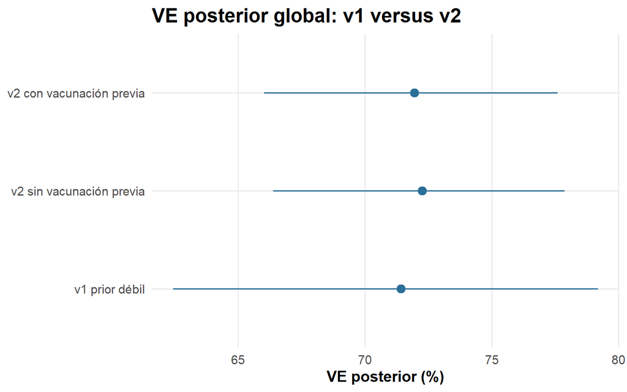

Efecto posterior de `vacunacion_previa` en el modelo ajustado.

| estimand | mediana | hpdi_inf | hpdi_sup |
| --- | --- | --- | --- |
| beta_prev | -0.249 | -0.468 | -0.028 |
| OR_prev | 0.780 | 0.613 | 0.955 |
| 1 - OR_prev | 0.220 | 0.045 | 0.387 |

P(OR asociado a `vacunacion_previa` < 1 | datos) = 0.988

La vacunación previa muestra una asociación protectora adicional: OR mediana 0.78, HPDI 95% [0.61, 0.96], con `P(OR < 1 | datos) = 0.988`. La lectura es asociativa, porque `vacunacion_previa` puede capturar historia de riesgo y acceso a vacunación, no solo biología inmunológica.

## Tabla temporal v2 Beta-Binomial

| prior | peso_efectivo | bin_tiempo | n | hospitalizadas | tasa_obs | tasa_obs_no_vacunadas | VE_mediana | VE_hpdi_inf | VE_hpdi_sup |
| --- | --- | --- | --- | --- | --- | --- | --- | --- | --- |
| Beta(1,1) | 2 | No vacunada | 10156 | 266 | 2.62 | 2.62 | 0.0 | 0.0 | 0.0 |
| Beta(1,1) | 2 | 0-90 | 1432 | 6 | 0.42 | 2.62 | 82.2 | 67.1 | 94.1 |
| Beta(1,1) | 2 | 91-180 | 4272 | 24 | 0.56 | 2.62 | 78.0 | 68.5 | 86.6 |
| Beta(1,1) | 2 | 181-270 | 4800 | 61 | 1.27 | 2.62 | 51.3 | 37.7 | 64.4 |
| Beta(1,1) | 2 | 271-365 | 4340 | 62 | 1.43 | 2.62 | 45.0 | 29.7 | 59.9 |
| Beta(2,8) | 10 | No vacunada | 10156 | 266 | 2.62 | 2.62 | 0.0 | 0.0 | 0.0 |
| Beta(2,8) | 10 | 0-90 | 1432 | 6 | 0.42 | 2.62 | 79.7 | 63.2 | 91.6 |
| Beta(2,8) | 10 | 91-180 | 4272 | 24 | 0.56 | 2.62 | 77.2 | 67.2 | 85.2 |
| Beta(2,8) | 10 | 181-270 | 4800 | 61 | 1.27 | 2.62 | 50.7 | 36.4 | 63.3 |
| Beta(2,8) | 10 | 271-365 | 4340 | 62 | 1.43 | 2.62 | 44.6 | 28.5 | 58.3 |

Probabilidades posteriores temporales v2.

| prior | P(VE_271-365 < VE_0-90 \| datos) | P(VE_271-365 > 0 \| datos) |
| --- | --- | --- |
| Beta(1,1) | 1.000 | 1 |
| Beta(2,8) | 0.999 | 1 |

El patrón temporal se mantiene respecto de v1: la VE es alta en los bins tempranos y menor en los bins tardíos. En v2, para `Beta(1,1)`, `P(VE_271-365 < VE_0-90 | datos)` queda en 1.000, prácticamente 1.

## Comparación v1 vs v2: tiempo, edad x tiempo y quejas

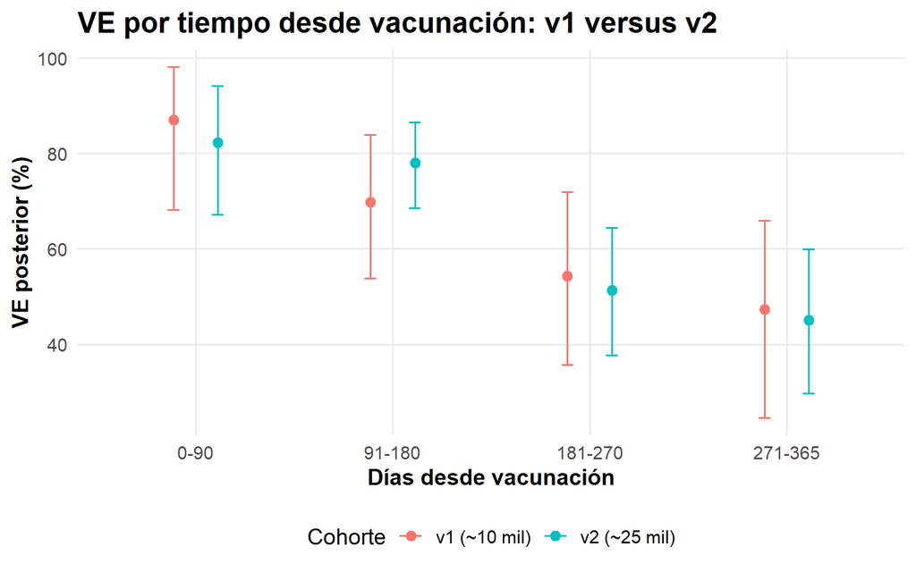

Resumen temporal v1 vs v2 para `Beta(1,1)`, excluyendo la referencia no vacunada.

| cohorte | bin_tiempo | n | hospitalizadas | VE_mediana_pct | HPDI_inf_pct | HPDI_sup_pct |
| --- | --- | --- | --- | --- | --- | --- |
| v1 (~10 mil) | 0-90 | 622 | 2 | 87.0 | 68.1 | 98.1 |
| v1 (~10 mil) | 91-180 | 1688 | 16 | 69.8 | 53.8 | 83.8 |
| v1 (~10 mil) | 181-270 | 1921 | 28 | 54.3 | 35.7 | 72.0 |
| v1 (~10 mil) | 271-365 | 1667 | 28 | 47.4 | 24.6 | 65.9 |
| v2 (~25 mil) | 0-90 | 1432 | 6 | 82.2 | 67.1 | 94.1 |
| v2 (~25 mil) | 91-180 | 4272 | 24 | 78.0 | 68.5 | 86.6 |
| v2 (~25 mil) | 181-270 | 4800 | 61 | 51.3 | 37.7 | 64.4 |
| v2 (~25 mil) | 271-365 | 4340 | 62 | 45.0 | 29.7 | 59.9 |

### Grilla edad x tiempo v2

Grilla v2 con conteos crudos y VE bayesiana.

| grupo_edad | bin | n_V | n_NV | hosp_V | hosp_NV | VE_mediana | HPDI_lo | HPDI_hi | celda_inestable | motivo_inestabilidad | riesgo_obs_V | riesgo_obs_NV | nota |
| --- | --- | --- | --- | --- | --- | --- | --- | --- | --- | --- | --- | --- | --- |
| 18-49 | 0-90 | 873 | 3492 | 1 | 34 | 80.9 | 42.1 | 99.4 | TRUE | hosp_V < 3 | 0.11 | 0.97 | inestable: hosp_V < 3 |
| 18-49 | 91-180 | 933 | 3492 | 1 | 34 | 82.2 | 46.5 | 99.3 | TRUE | hosp_V < 3 | 0.11 | 0.97 | inestable: hosp_V < 3 |
| 18-49 | 181-270 | 652 | 3492 | 2 | 34 | 58.8 | -0.9 | 95.2 | TRUE | hosp_V < 3; HPDI ancho | 0.31 | 0.97 | inestable: hosp_V < 3; HPDI ancho |
| 18-49 | 271-365 | 0 | 3492 | 0 | 34 | NA | NA | NA | TRUE | n_V = 0 | NA | 0.97 | inestable: n_V = 0 |
| 50-64 | 0-90 | 411 | 3175 | 3 | 74 | 62.3 | 18.7 | 94.3 | TRUE | HPDI ancho | 0.73 | 2.33 | inestable: HPDI ancho |
| 50-64 | 91-180 | 1261 | 3175 | 4 | 74 | 84.2 | 67.3 | 95.9 | FALSE | ok | 0.32 | 2.33 | ok |
| 50-64 | 181-270 | 1231 | 3175 | 6 | 74 | 76.8 | 56.5 | 92.0 | FALSE | ok | 0.49 | 2.33 | ok |
| 50-64 | 271-365 | 1319 | 3175 | 7 | 74 | 75.2 | 54.9 | 91.2 | FALSE | ok | 0.53 | 2.33 | ok |
| 65+ | 0-90 | 148 | 3489 | 2 | 158 | 60.5 | 5.0 | 95.0 | TRUE | hosp_V < 3; HPDI ancho | 1.35 | 4.53 | inestable: hosp_V < 3; HPDI ancho |
| 65+ | 91-180 | 2078 | 3489 | 19 | 158 | 79.2 | 68.9 | 88.2 | FALSE | ok | 0.91 | 4.53 | ok |
| 65+ | 181-270 | 2917 | 3489 | 53 | 158 | 59.7 | 46.5 | 71.1 | FALSE | ok | 1.82 | 4.53 | ok |
| 65+ | 271-365 | 3021 | 3489 | 55 | 158 | 59.5 | 46.6 | 71.2 | FALSE | ok | 1.82 | 4.53 | ok |

Celda `65+ x 181-270` en la cohorte v2.

| grupo_edad | bin | n_V | n_NV | hosp_V | hosp_NV | VE_mediana | HPDI_lo | HPDI_hi | celda_inestable | motivo_inestabilidad | riesgo_obs_V | riesgo_obs_NV |
| --- | --- | --- | --- | --- | --- | --- | --- | --- | --- | --- | --- | --- |
| 65+ | 181-270 | 2917 | 3489 | 53 | 158 | 59.7 | 46.5 | 71.1 | FALSE | ok | 1.82 | 4.53 |

Comparada con v1, la celda `65+ x 181-270` conserva protección positiva, aunque con una estimación algo menor en la cohorte ampliada. En v1 fue aproximadamente 64.4% [47.7, 79.7], mientras que en v2 queda aproximadamente 59.7% [46.5, 71.1].

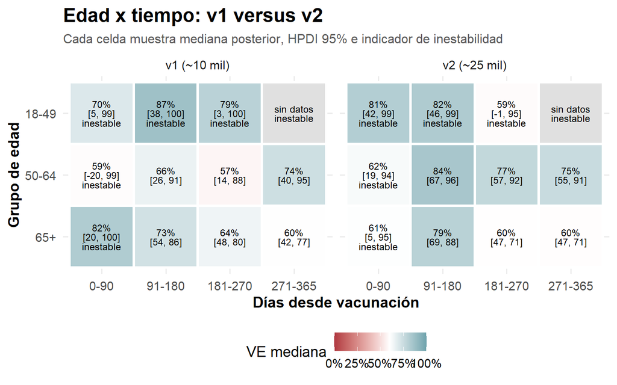

Resumen edad x tiempo v1 vs v2.

| cohorte | grupo_edad | bin | n_V | n_NV | hosp_V | hosp_NV | VE_mediana_pct | HPDI_lo_pct | HPDI_hi_pct | celda_inestable |
| --- | --- | --- | --- | --- | --- | --- | --- | --- | --- | --- |
| v1 (~10 mil) | 18-49 | 0-90 | 407 | 1399 | 1 | 18 | 69.5 | 4.6 | 98.8 | TRUE |
| v1 (~10 mil) | 18-49 | 91-180 | 379 | 1399 | 0 | 18 | 86.5 | 38.1 | 100.0 | TRUE |
| v1 (~10 mil) | 18-49 | 181-270 | 250 | 1399 | 0 | 18 | 79.0 | 3.5 | 100.0 | TRUE |
| v1 (~10 mil) | 18-49 | 271-365 | 0 | 1399 | 0 | 18 | NA | NA | NA | TRUE |
| v1 (~10 mil) | 50-64 | 0-90 | 149 | 1406 | 1 | 38 | 59.2 | -19.5 | 98.6 | TRUE |
| v1 (~10 mil) | 50-64 | 91-180 | 491 | 1406 | 4 | 38 | 65.6 | 26.2 | 91.2 | FALSE |
| v1 (~10 mil) | 50-64 | 181-270 | 480 | 1406 | 5 | 38 | 57.0 | 14.1 | 87.6 | FALSE |
| v1 (~10 mil) | 50-64 | 271-365 | 509 | 1406 | 3 | 38 | 73.7 | 40.3 | 95.1 | FALSE |
| v1 (~10 mil) | 65+ | 0-90 | 66 | 1531 | 0 | 85 | 81.9 | 20.5 | 100.0 | TRUE |
| v1 (~10 mil) | 65+ | 91-180 | 818 | 1531 | 12 | 85 | 72.5 | 53.9 | 86.4 | FALSE |
| v1 (~10 mil) | 65+ | 181-270 | 1191 | 1531 | 23 | 85 | 64.4 | 47.7 | 79.7 | FALSE |
| v1 (~10 mil) | 65+ | 271-365 | 1158 | 1531 | 25 | 85 | 60.4 | 41.9 | 76.7 | FALSE |
| v2 (~25 mil) | 18-49 | 0-90 | 873 | 3492 | 1 | 34 | 80.9 | 42.1 | 99.4 | TRUE |
| v2 (~25 mil) | 18-49 | 91-180 | 933 | 3492 | 1 | 34 | 82.2 | 46.5 | 99.3 | TRUE |
| v2 (~25 mil) | 18-49 | 181-270 | 652 | 3492 | 2 | 34 | 58.8 | -0.9 | 95.2 | TRUE |
| v2 (~25 mil) | 18-49 | 271-365 | 0 | 3492 | 0 | 34 | NA | NA | NA | TRUE |
| v2 (~25 mil) | 50-64 | 0-90 | 411 | 3175 | 3 | 74 | 62.3 | 18.7 | 94.3 | TRUE |
| v2 (~25 mil) | 50-64 | 91-180 | 1261 | 3175 | 4 | 74 | 84.2 | 67.3 | 95.9 | FALSE |
| v2 (~25 mil) | 50-64 | 181-270 | 1231 | 3175 | 6 | 74 | 76.8 | 56.5 | 92.0 | FALSE |
| v2 (~25 mil) | 50-64 | 271-365 | 1319 | 3175 | 7 | 74 | 75.2 | 54.9 | 91.2 | FALSE |
| v2 (~25 mil) | 65+ | 0-90 | 148 | 3489 | 2 | 158 | 60.5 | 5.0 | 95.0 | TRUE |
| v2 (~25 mil) | 65+ | 91-180 | 2078 | 3489 | 19 | 158 | 79.2 | 68.9 | 88.2 | FALSE |
| v2 (~25 mil) | 65+ | 181-270 | 2917 | 3489 | 53 | 158 | 59.7 | 46.5 | 71.1 | FALSE |
| v2 (~25 mil) | 65+ | 271-365 | 3021 | 3489 | 55 | 158 | 59.5 | 46.6 | 71.2 | FALSE |

### Respuestas operativas v1 vs v2

#### Queja 1: vacunación hace aproximadamente 14 meses

Catorce meses sigue fuera del soporte directo: el dataset llega hasta 365 días. Para comparar v1 y v2 se usa el bin observado más cercano, `271-365`, con la misma lógica Beta-Binomial descriptiva.

| cohorte | prior | VE_tardia_mediana_pct | HPDI_inf_pct | HPDI_sup_pct | prob_tardia_menor_0_90_pct | prob_tardia_mayor_0_pct |
| --- | --- | --- | --- | --- | --- | --- |
| v1 (~10 mil) | Beta(1,1) | 47.5 | 24.5 | 66.2 | 99.6 | 100.0 |
| v1 (~10 mil) | Beta(2,8) | 45.8 | 22.6 | 64.9 | 99.0 | 99.9 |
| v2 (~25 mil) | Beta(1,1) | 45.0 | 29.7 | 59.9 | 100.0 | 100.0 |
| v2 (~25 mil) | Beta(2,8) | 44.6 | 28.5 | 58.3 | 99.9 | 100.0 |

La respuesta bayesiana se mantiene: en ambas cohortes la VE tardía queda por debajo de la VE del bin `0-90` con alta probabilidad posterior, aunque los intervalos se actualizan con la cohorte ampliada. La magnitud de la mediana tardía no cambia materialmente en v2.

Respuesta operativa: la hospitalización 14 meses después de vacunarse sigue siendo compatible con riesgo residual y posible atenuación respecto del pico observado. No implica que la vacuna no haya funcionado y no permite extrapolar directamente más allá de 365 días.

#### Queja 2: paciente de 72 años, vacunada hace aproximadamente 9 meses

La comparación usa la celda `65+ x 181-270` en ambas cohortes y mantiene la referencia contra no vacunadas del mismo grupo etario, sin ajustar por `vacunacion_previa`.

| cohorte | n_V | n_NV | hosp_V | hosp_NV | VE_mediana_pct | HPDI_inf_pct | HPDI_sup_pct | prob_VE_mayor_0_pct | prob_VE_mayor_50_pct |
| --- | --- | --- | --- | --- | --- | --- | --- | --- | --- |
| v1 (~10 mil) | 1191 | 1531 | 23 | 85 | 64.5 | 47.5 | 79.4 | 100 | 94.0 |
| v2 (~25 mil) | 2917 | 3489 | 53 | 158 | 59.5 | 46.2 | 71.0 | 100 | 91.4 |

La respuesta bayesiana se mantiene: ambas cohortes favorecen VE positiva para `65+ x 181-270`, con intervalos actualizados por la cohorte ampliada. La magnitud de la mediana no cambia materialmente en v2.

Respuesta operativa: para una paciente de 72 años vacunada hace 9 meses, la lectura sigue siendo probabilística y poblacional. La protección estimada no es absoluta; la decisión de refuerzo corresponde a una política sanitaria general de duración y riesgo, no a inferir fracaso individual desde una hospitalización.

# Discusión ética y límites del reanálisis

El reanálisis con la cohorte ampliada no invalida el estudio original: mantiene la dirección posterior observada en v1, aunque actualiza magnitudes e intervalos. Para la Queja 1, la VE tardía en `271-365` días pasa de 47.5% [24.5, 66.2] en v1 a 45.0% [29.7, 59.9] en v2, y `P(VE_271-365 < VE_0-90 | datos)` pasa de 99.6% a 100%. La interpretación operativa se mantiene: riesgo residual y protección menor que en el bin temprano, sin extrapolar directamente a 14 meses porque el soporte observado llega a 365 días.

Para la Queja 2, la celda `65+ x 181-270` pasa de 64.5% [47.5, 79.4] en v1 a 59.5% [46.2, 71.0] en v2. La probabilidad posterior de VE mayor a 50% baja de 94.0% a 91.4%, pero sigue sosteniendo una conclusión poblacional compatible con protección relevante y no absoluta.

El DAG, el Paso 6 y el Paso 7 cumplen funciones distintas. El DAG explicita supuestos causales y estructura de identificación; no necesita una versión nueva por tener más filas. `vacunacion_previa` agrega información medida y puede funcionar como proxy parcial de historia de riesgo, pero no elimina el confusor latente `U`. Por eso la sensibilidad a confusor no medido del Paso 6 sigue siendo un límite común a v1 y v2: la cohorte ampliada aporta robustez descriptiva, no identificación causal plena. El WAIC original cumple la consigna metodológica de comparación predictiva; repetirlo para la cohorte ampliada sería accesorio y podría distraer de la respuesta operativa a las quejas.

Límites concretos:

- La confusión no medida puede desplazar el efecto observado; el Paso 6 muestra sensibilidad, pero no identifica completamente ese sesgo.
- Falta información de persona-tiempo y calendario, por lo que las comparaciones por tiempo desde vacunación son descriptivas y exploratorias.
- El soporte directo de los datos llega hasta 365 días; no corresponde extrapolar automáticamente a 14 meses.
- Algunas celdas edad x tiempo tienen pocos datos o `n_V = 0`, por lo que sus medianas e intervalos deben tratarse como inestables.

La comunicación responsable evita dos errores: prometer protección individual absoluta y convertir un análisis exploratorio en una recomendación clínica directa. La lectura adecuada es poblacional, probabilística y condicionada por las limitaciones del diseño observacional.